# Nuuk Fjord: Drivers of shrub abundance - beta-binomial mixture model, separated by species

Jonathan von Oppen

21 July 2020

```r
rm(list = ls())
```

## Dependencies

Packages included:

- tidyverse - for convenient code flow, data wrangling and plotting
- rjags & R2jags - to link JAGS and R
- skimr - for data summary
- corrr - to output correlation matrices in dataframe format
- cowplot & patchwork - to combine plot panels
- Rmarkdown - to produce this neat little documentation

```r
# load pacman package from the repository, if you do not already have it
if (!require('pacman')) install.packages('pacman', repos="https://cloud.r-project.org")
pacman::p_load(tidyverse, # set of packages for data manipulation, exploration and visualisation
               rjags,     # to link JAGS and R
               R2jags,    # to link JAGS and R
               skimr,     # for quick dataframe inspection
               corrr,     # output correlation matrices as data frame
               cowplot,   # combine plot panels
               patchwork, # -"-
               rmarkdown) # for R Markdown formatting
```

Functions used:

- effect size plot function

```r
model_plot_function <- function(model_coeff_output) {
  target_vars <- c("b.tempjja.x", "b.tempjja.x2",
                   "b.tempcont.x", "b.tempcont.x2",
                   "b.precipjja.x", "b.precipjja.x2",
                   "b.sri",
                   "b.tri",
                   "b.twi_90m",
                   "b.compet")
  solutions <- model_coeff_output
  names(solutions) <- c("variable", "post.mean", "post.sd", "l95", "l90", "u90", "u95", "Rhat")
  solutions <- solutions %>%
    filter(variable %in% target_vars)
  # solutions$variable <- factor(solutions$variable,
  #                               levels = c("b.tempjja.x", "b.tempjja.x2",
  #                                          "b.tempcont.x", "b.tempcont.x2",
  #                                          "b.precipjja.x", "b.precipjja.x2",
  #                                          "b.sri",
  #                                          "b.tri",
  #                                          "b.twi_90m",
  #                                          "b.compet"))
  min_value <- floor(min(solutions$l95))
  max_value <- ceiling(max(solutions$u95))
  solutions$sig <- "ns"
  solutions$sig[solutions$l95 < 0 & solutions$u95 < 0] <- "sig"
  solutions$sig[solutions$l95 > 0 & solutions$u95 > 0] <- "sig"
  label_colour <- rep("black", nrow(solutions))
  label_colour[solutions$sig == "sig"] <- theme_darkgreen
  label_face <- rep("plain", nrow(solutions))
  label_face[solutions$sig == "sig"] <- "bold"
  # label_face[response == "T1_mean" & solutions$sig == "sig"] <- "bold"
  title_colour <- "black"
  # if(response == "T1_mean" | response == "T1_amp") title_colour <- theme_red
  # if(response == "T2_mean" | response == "T2_amp") title_colour <- theme_yellow
  # if(response == "T1_mean") response <- "Soil"
  # if(response == "T2_mean") response <- "Ground"


  model_plot <- ggplot(solutions, aes(x = variable, y = post.mean,
                                      ymin = l95, ymax = u95,
                                      colour = sig)) +
    geom_point() +
    geom_errorbar(width = .8) +
    theme_cowplot(18) +
    ylab("Effect Size (scaled)") +
    xlab("") +
    #ggtitle("Betula nana") + # (paste0(response))
    scale_colour_manual(values = c("black", theme_darkgreen)) +
    scale_y_continuous(limits = c(min_value, max_value), breaks = seq(min_value,max_value,0.5)) +
    # scale_x_discrete(limits = c("b.tempjja.x", "b.tempjja.x2",
    #         "b.tempcont.x", "b.tempcont.x2",
    #         "b.precipjja.x", "b.precipjja.x2",
    #         "b.sri",
    #         "b.tri",
    #         "b.twi_90m",
    #         "b.compet"),
    #                  labels = c("summer temperature", bquote(.("summer") *" "* temperature^2),
    #                             "temperature variability", bquote(.("temperature") *" "* variability^2),
    #                             "summer precipitation", bquote(.("summer") *" "* precipitation^2),
    #                             "solar radiation",
  #                             "terrain ruggedness",
  #                             "moisture availability",
  #                             "competition")) +
  annotate("segment", x = 0, xend = 11, y = 0, yend = 0) +
    theme(axis.text.x = element_text(angle = 45, hjust = 1, colour = label_colour, face = label_face),
          plot.title = element_text(colour = title_colour, face = "italic"),
          legend.position = "none")
  return(model_plot)
}
```

Colour scheme:

```r
# Colour scheme ####
theme_red <- "#E64447FF"
theme_blue <- "#12435DFF"
theme_lightblue <- "#1FA3AEFF"
theme_grey <- "#EDEDEDFF"
theme_yellow <- "#EEBE5BFF"

# additional colours
theme_darkblue <- "#1D5799"
theme_darkgreen <- "#13944D"
theme_orange <- "#B56A24"
theme_purple <- "#8757B3"
```

## Single-species models

This dataset is a new one containing predictors extracted from downscaled CHELSA climate data.

Analyses conducted on fusion table at **plot $\times$ taxon level** (as we are explicitly interested in plot-level variation of predictors, esp. slope, solar radiation, terrain ruggedness, topographical wetness, and competition): 3726 observations for 38 variables

```r
env_cov_bio <- read.csv("../data/nuuk_env_cover_plots.csv", header = T)
```

### Prepare data for JAGS model

### a) selection of variables relevant for analysis

including predictors

- Information on site, plot, plot group, sampling location (lat, lon, altitude), sampling year
- downscaled CHELSA predictors, averaged over a 30-year period (*[…]_ts_30*)
- solar radiation index (SRI, following [Keating et al. 2007](http://www.bioone.org/doi/abs/10.2193/2006-359)), slope (erosion measure), Terrain Ruggedness Index (TRI, following [Riley et al. 1999](http://download.osgeo.org/qgis/doc/reference-docs/Terrain_Ruggedness_Index.pdf)), Normalised Difference Wetness Index (NDWI, [Gao 1996](https://www.sciencedirect.com/science/article/pii/S0034425796000673)), Tasseled Cap Wetness Index (TCWI, [Crist & Ciccone 1984](https://ieeexplore.ieee.org/document/4157507)), SAGA Topographic Wetness Index (TWI, see [Conrad et al. 2015](https://gmd.copernicus.org/articles/8/1991/2015/) and the [index documentation](http://www.saga-gis.org/saga_tool_doc/2.2.2/ta_hydrology_15.html))
- taxon (see above for levels)
- competition pressure in the community (as summed abundance of taller-growing shrub species within a plot, averaged within plot groups)

and response variable

- cover (as relative no. hits per plot for each species)

```r
env_cov_bio_sub <- env_cov_bio %>%
  select(site_alt_plotgroup_id, plot, site, site_alt_id, year, long, lat, alt,  # plot info / metadata
  ends_with("_ts_30"),   # CHELSA predictors averaged over 10-year period prior to study year
  inclin_down, twi_90m, tri, sri,
  #mean_summ_ndvi_yos, cv_mean_summ_ndvi_2001_to_yos, Perc_dist_coast_lines,   # environmental data
  taxon, cover, compet)   # taxon, cover response, competition pressure
head(env_cov_bio_sub)
```

|  | site_alt_plotgroup_id | plot | site | site_alt_id | year | long | lat | alt | tempjja_ts_30 | tempmax_ts_30 | tempmin_ts_30 | tempcont_ts_30 | precipjja_ts_30 | precipjfmam_ts_30 | precipmam_ts_30 | inclin_down | twi_90m | tri | sri | taxon | cover | compet |
| --- | --- | --- | --- | --- | --- | --- | --- | --- | --- | --- | --- | --- | --- | --- | --- | --- | --- | --- | --- | --- | --- | --- |
| 1 | 1_20_1 | P145 | 1 | 1_20 | 2011 | -51.78662 | 64.23933 | 20 | 9.352377 | 10.57648 | -14.35101 | 24.92749 | 213.5949 | 267.4649 | 126.8913 | 12 | 6.657241 | 0.2808821 | 0.9330854 | Betula nana | 0.00 | 5 |
| 2 | 1_20_1 | P145 | 1 | 1_20 | 2011 | -51.78662 | 64.23933 | 20 | 9.352377 | 10.57648 | -14.35101 | 24.92749 | 213.5949 | 267.4649 | 126.8913 | 12 | 6.657241 | 0.2808821 | 0.9330854 | Cassiope tetragona | 0.00 | 23 |
| 3 | 1_20_1 | P145 | 1 | 1_20 | 2011 | -51.78662 | 64.23933 | 20 | 9.352377 | 10.57648 | -14.35101 | 24.92749 | 213.5949 | 267.4649 | 126.8913 | 12 | 6.657241 | 0.2808821 | 0.9330854 | Empetrum nigrum | 0.72 | 5 |
| 4 | 1_20_1 | P145 | 1 | 1_20 | 2011 | -51.78662 | 64.23933 | 20 | 9.352377 | 10.57648 | -14.35101 | 24.92749 | 213.5949 | 267.4649 | 126.8913 | 12 | 6.657241 | 0.2808821 | 0.9330854 | Rhododendron groenlandicum | 0.00 | 0 |
| 5 | 1_20_1 | P145 | 1 | 1_20 | 2011 | -51.78662 | 64.23933 | 20 | 9.352377 | 10.57648 | -14.35101 | 24.92749 | 213.5949 | 267.4649 | 126.8913 | 12 | 6.657241 | 0.2808821 | 0.9330854 | Rhododendron tomentosum | 0.00 | 0 |
| 6 | 1_20_1 | P145 | 1 | 1_20 | 2011 | -51.78662 | 64.23933 | 20 | 9.352377 | 10.57648 | -14.35101 | 24.92749 | 213.5949 | 267.4649 | 126.8913 | 12 | 6.657241 | 0.2808821 | 0.9330854 | Phyllodoce caerulea | 0.00 | 23 |

Let’s check for correlation between the different moisture predictors and terrain ruggedness:

```r
(cor_moist <- env_cov_bio %>%
  select(twi_90m, ndwi, tcws, tri)) %>%
  correlate(diagonal = 1)
```

```
##
## Correlation method: 'pearson'
## Missing treated using: 'pairwise.complete.obs'
```

| rowname | twi_90m | ndwi | tcws | tri |
| --- | --- | --- | --- | --- |
| twi_90m | 1.0000000 | 0.27638209 | 0.2652426 | -0.29124871 |
| ndwi | 0.2763821 | 1.00000000 | 0.8729343 | 0.05107939 |
| tcws | 0.2652426 | 0.87293433 | 1.0000000 | 0.13978839 |
| tri | -0.2912487 | 0.05107939 | 0.1397884 | 1.00000000 |

$\Rightarrow$ NDWI and TCWS are highly correlated, but both are largely independent from TWI and TRI. We’ll go with TWI for now, as it is least confounded by vegetation, but will have to discuss maybe including a second index, depending on hypothesis/ecological implication.

Predictors don’t always vary between plots within plotgroups - perhaps due to several falling into the same CHELSA grid cell.

Example: plots within site 1, altitude 20, plot group 1: plot P146 is slightly off and therefore has different climate variables than the other ones

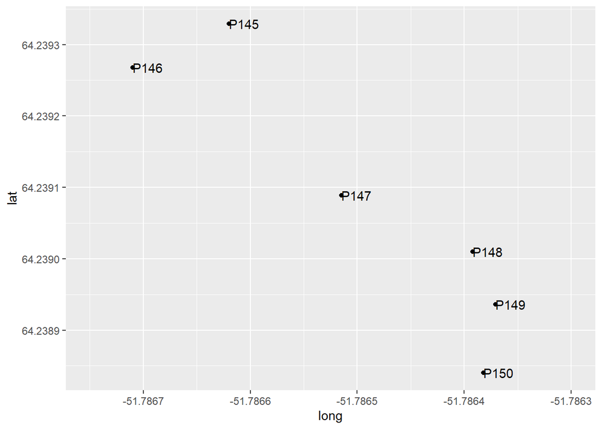

```r
env_cov_bio %>% filter(taxon == "Betula nana" & site_alt_plotgroup_id == "1_20_1") %>%
  ggplot(aes(x = long, y = lat)) +
  geom_point() +
  geom_text(aes(label = plot), hjust = 0.0001) +
  xlim(c(-51.78675, -51.7863))
```

```r
env_cov_bio %>% filter(taxon == "Betula nana" & site_alt_plotgroup_id == "1_20_1") %>%
  select(site_alt_plotgroup_id, plot, tempjja_ts_30)
```

| site_alt_plotgroup_id | plot | tempjja_ts_30 |
| --- | --- | --- |
| 1_20_1 | P145 | 9.352377 |
| 1_20_1 | P146 | 9.345625 |
| 1_20_1 | P147 | 9.352377 |
| 1_20_1 | P148 | 9.352377 |
| 1_20_1 | P149 | 9.352377 |
| 1_20_1 | P150 | 9.352377 |

Check for correlation between predictors:

```r
predictors_set <- env_cov_bio_sub %>%
  select(ends_with("_ts_30"),   # CHELSA predictors averaged over 10-year period prior to study year
         inclin_down, twi_90m, tri, sri,    # environmental data
         compet, alt) %>%
  names()
# create basic correlation matrix
(cor_mat <- env_cov_bio_sub %>%
  dplyr::select(predictors_set) %>%
  correlate(diagonal = 1) %>%
  # drop all values < .4 to increase readability
  mutate_if(is.numeric, ~ ifelse(abs(.) < .4, NA, .)))
```

```
##
## Correlation method: 'pearson'
## Missing treated using: 'pairwise.complete.obs'
```

| rowname | tempjja_ts_30 | tempmax_ts_30 | tempmin_ts_30 | tempcont_ts_30 | precipjja_ts_30 | precipjfmam_ts_30 | precipmam_ts_30 | inclin_down | twi_90m | tri | sri | compet | alt |
| --- | --- | --- | --- | --- | --- | --- | --- | --- | --- | --- | --- | --- | --- |
| tempjja_ts_30 | 1.0000000 | 0.9991917 | 0.4975328 | NA | 0.4230620 | NA | NA | NA | NA | NA | NA | NA | NA |
| tempmax_ts_30 | 0.9991917 | 1.0000000 | 0.4667132 | NA | 0.4146652 | NA | NA | NA | NA | NA | NA | NA | NA |
| tempmin_ts_30 | 0.4975328 | 0.4667132 | 1.0000000 | -0.8254350 | 0.7132677 | 0.8297730 | 0.6801256 | NA | NA | NA | NA | NA | -0.4801835 |
| tempcont_ts_30 | NA | NA | -0.8254350 | 1.0000000 | -0.5365618 | -0.7427378 | -0.6430719 | NA | NA | NA | NA | NA | NA |
| precipjja_ts_30 | 0.4230620 | 0.4146652 | 0.7132677 | -0.5365618 | 1.0000000 | 0.9372096 | 0.9184609 | NA | NA | NA | NA | NA | NA |
| precipjfmam_ts_30 | NA | NA | 0.8297730 | -0.7427378 | 0.9372096 | 1.0000000 | 0.9674715 | NA | NA | NA | NA | NA | NA |
| precipmam_ts_30 | NA | NA | 0.6801256 | -0.6430719 | 0.9184609 | 0.9674715 | 1.0000000 | NA | NA | NA | NA | NA | NA |
| inclin_down | NA | NA | NA | NA | NA | NA | NA | 1.0000000 | NA | 0.6759513 | -0.9578188 | NA | NA |
| twi_90m | NA | NA | NA | NA | NA | NA | NA | NA | 1.0000000 | NA | NA | NA | -0.5258371 |
| tri | NA | NA | NA | NA | NA | NA | NA | 0.6759513 | NA | 1.0000000 | -0.6392933 | NA | NA |

[output cut: 3 more lines]

$\Rightarrow$ Maximum temperature is highly correlated with JJA temperature, minimum temperature with continentality, slope (inclin_down) with solar radiation, and spring precipitation variables with JJA precipitation. Let’s exclude them step by step and check the variance inflation factors (VIF) along the way. VIF values > 10 indicate collinearity issues.

```r
# for the whole set of predictors
(vif_predictors_1 <- env_cov_bio_sub %>%
  dplyr::select(predictors_set) %>%
  usdm::vif()) #%>% View()
```

| Variables | VIF |
| --- | --- |
| tempjja_ts_30 | 44654.378081 |
| tempmax_ts_30 | Inf |
| tempmin_ts_30 | Inf |
| tempcont_ts_30 | Inf |
| precipjja_ts_30 | 22.759358 |
| precipjfmam_ts_30 | 663.383140 |
| precipmam_ts_30 | 236.648024 |
| inclin_down | 14.694235 |
| twi_90m | 2.202029 |
| tri | 2.033146 |

[output cut: 3 more lines]

```r
# => drop tempmax (correlated w/ tempjja)
(vif_predictors_2 <- env_cov_bio_sub %>%
  dplyr::select(predictors_set,
                -tempmax_ts_30) %>%
  usdm::vif()) #%>% View()
```

| Variables | VIF |
| --- | --- |
| tempjja_ts_30 | 4.465438e+04 |
| tempmin_ts_30 | 1.463220e+05 |
| tempcont_ts_30 | 1.051274e+05 |
| precipjja_ts_30 | 2.275936e+01 |
| precipjfmam_ts_30 | 6.633831e+02 |
| precipmam_ts_30 | 2.366480e+02 |
| inclin_down | 1.469423e+01 |
| twi_90m | 2.202029e+00 |
| tri | 2.033146e+00 |
| sri | 1.337676e+01 |

[output cut: 2 more lines]

```r
# => drop tempmin (correlated w/ tempcont)
(vif_predictors_3 <- env_cov_bio_sub %>%
  dplyr::select(predictors_set,
                -tempmax_ts_30,
                -tempmin_ts_30) %>%
  usdm::vif()) #%>% View()
```

| Variables | VIF |
| --- | --- |
| tempjja_ts_30 | 8.219533 |
| tempcont_ts_30 | 24.066415 |
| precipjja_ts_30 | 20.909985 |
| precipjfmam_ts_30 | 231.102890 |
| precipmam_ts_30 | 84.070139 |
| inclin_down | 14.584996 |
| twi_90m | 2.201590 |
| tri | 2.026541 |
| sri | 13.303925 |
| compet | 1.056189 |

[output cut: 1 more lines]

```r
# => drop precipjfmam (correlated w/ precipjja & tempcont)
(vif_predictors_4 <- env_cov_bio_sub %>%
  dplyr::select(predictors_set,
                -tempmax_ts_30,
                -tempmin_ts_30,
                -contains("jfm")) %>%
  usdm::vif()) #%>% View()
```

| Variables | VIF |
| --- | --- |
| tempjja_ts_30 | 2.810697 |
| tempcont_ts_30 | 3.613073 |
| precipjja_ts_30 | 11.151763 |
| precipmam_ts_30 | 11.789118 |
| inclin_down | 13.754173 |
| twi_90m | 1.964142 |
| tri | 1.979090 |
| sri | 12.668007 |
| compet | 1.046531 |
| alt | 3.330663 |

```r
# => drop inclin_down (correlated w/ SRI)
(vif_predictors_5 <- env_cov_bio_sub %>%
  dplyr::select(predictors_set,
                -tempmax_ts_30,
                -tempmin_ts_30,
                -inclin_down,
                -contains("jfm")) %>%
  usdm::vif()) #%>% View()
```

| Variables | VIF |
| --- | --- |
| tempjja_ts_30 | 2.794535 |
| tempcont_ts_30 | 3.594908 |
| precipjja_ts_30 | 10.948147 |
| precipmam_ts_30 | 11.480886 |
| twi_90m | 1.960529 |
| tri | 1.827662 |
| sri | 1.827745 |
| compet | 1.045716 |
| alt | 3.316703 |

```r
(vif_predictors_6 <- env_cov_bio_sub %>%
  dplyr::select(predictors_set,
                -tempmax_ts_30,
                -tempmin_ts_30,
                -inclin_down,
                -contains("mam")) %>%
  usdm::vif()) #%>% View()
```

| Variables | VIF |
| --- | --- |
| tempjja_ts_30 | 2.767199 |
| tempcont_ts_30 | 2.847897 |
| precipjja_ts_30 | 3.087378 |
| twi_90m | 1.956647 |
| tri | 1.827644 |
| sri | 1.804655 |
| compet | 1.045467 |
| alt | 2.956003 |

All VIF are now < 3.1 -> OK! We can now exclude the dropped variables to obtain the final dataset:

```r
env_cov_bio_sub <- env_cov_bio_sub %>%
  dplyr::select(-tempmax_ts_30,
                -tempmin_ts_30,
                -inclin_down,
                -contains("mam"))
```

### b) adjustion of data structure

Data was ordered by site/altitude/plotgroup and taxon

```r
env_cov_bio_sub <- env_cov_bio_sub[order(env_cov_bio_sub$site_alt_plotgroup_id, env_cov_bio_sub$taxon),]
```

As JAGS is only able to handle numeric input, all variables are assigned a numeric identifier:

```r
env_cov_bio_sub$plotgroup.NUM <- as.numeric(factor(env_cov_bio_sub$site_alt_plotgroup_id,
                                                   levels = unique(env_cov_bio_sub$site_alt_plotgroup_id)))
env_cov_bio_sub$plot.NUM <- as.numeric(factor(env_cov_bio_sub$plot,
                                              levels = unique(env_cov_bio_sub$plot)))
env_cov_bio_sub$site_alt.NUM <- as.numeric(factor(env_cov_bio_sub$site_alt_id,
                                              levels = unique(env_cov_bio_sub$site_alt_id)))
env_cov_bio_sub$site.NUM <- as.numeric(factor(env_cov_bio_sub$site, levels = unique(env_cov_bio_sub$site)))
env_cov_bio_sub$taxon.NUM <- as.numeric(factor(env_cov_bio_sub$taxon, levels = unique(env_cov_bio_sub$taxon)))
```

Taxa were coded as follows:

```r
data.frame(taxon = levels(env_cov_bio_sub$taxon),
           num = unique(env_cov_bio_sub$taxon.NUM))
```

| taxon | num |
| --- | --- |
| Betula nana | 1 |
| Cassiope tetragona | 2 |
| Empetrum nigrum | 3 |
| Phyllodoce caerulea | 4 |
| Rhododendron groenlandicum | 5 |
| Rhododendron tomentosum | 6 |
| Salix arctophila | 7 |
| Salix glauca | 8 |
| Vaccinium uliginosum | 9 |

Numeric predictors were scaled:

```r
num_pred <- env_cov_bio_sub %>% select(alt,
                                       ends_with("_ts_30"),
                                       sri,
                                       tri,
                                       starts_with("twi"),
                                       matches("compet"))
for(i in 1:length(num_pred)){
  col <- colnames(num_pred[i])
  env_cov_bio_sub[paste0(col,"C")] <- as.numeric(scale(num_pred[i], scale = TRUE, center = TRUE))
}
```

To account for the range of the cover response ($0 \leq cover \leq 1$), the model needs a mixed structure incorporating a beta distribution (for all continuous values with $0 < cover < 1$) and a binomial distribution (for all discrete values of $cover = \{0, 1\}$). An additional variable *cover_discrete* was introduced to separate the dataset into discrete (= 1) and continuous (= 0) cover values:

```r
env_cov_bio_sub$cover_discrete <- ifelse(env_cov_bio_sub$cover == 1 | env_cov_bio_sub$cover == 0, 1, 0)
```

### Trial: *Betula nana*

The dataset was then ready to be split up into the species of interest. As a first trial, I focused on *Betula nana*:

### > run & evaluate model

- quadratic fit better for temperature variables, linear fit better for precipitation variables
- tbc

### All species

The dataset was then ready to be split up into the species of interest. We create separate data subsets for all/discrete/continuous response variable values for each species:

```r
# split dataframe by taxon
env_cov_bio_sub_spec.tot <- split(env_cov_bio_sub, env_cov_bio_sub$taxon)

# assign taxon name to list elements
# >> for total datasets
for (taxon_id in 1:nlevels(env_cov_bio_sub$taxon)){
  # extract 3-letter genus name string
  assign(paste0(str_extract(levels(env_cov_bio_sub$taxon)[taxon_id],
                            "^\\w{3}"),
  # extract and capitalise 3-letter species name string
                str_to_title(str_remove(str_extract(levels(env_cov_bio_sub$taxon)[taxon_id],
                                                    "\\s\\w{3}"),
                                        "\\s")),
  # add extension
                ".tot"),
  # assign to respective list element
         env_cov_bio_sub_spec.tot[[taxon_id]])
}



# >> for discrete datasets
env_cov_bio_sub_spec.dis <- list()
for (taxon_id in 1:nlevels(env_cov_bio_sub$taxon)){
  # filter for discrete response values
  env_cov_bio_sub_spec.dis[[taxon_id]] <- filter(env_cov_bio_sub_spec.tot[[taxon_id]], cover_discrete == 1)
  # extract 3-letter genus name string
  assign(paste0(str_extract(levels(env_cov_bio_sub$taxon)[taxon_id],
                            "^\\w{3}"),
  # extract and capitalise 3-letter species name string
                str_to_title(str_remove(str_extract(levels(env_cov_bio_sub$taxon)[taxon_id],
                                                    "\\s\\w{3}"),
                                        "\\s")),
  # add extension
                ".dis"),
  # assign to respective list element
         env_cov_bio_sub_spec.dis[[taxon_id]])
}

# >> for continuous datasets
env_cov_bio_sub_spec.cont <- list()
for (taxon_id in 1:nlevels(env_cov_bio_sub$taxon)){
  # filter for continuous response values
  env_cov_bio_sub_spec.cont[[taxon_id]] <- filter(env_cov_bio_sub_spec.tot[[taxon_id]], cover_discrete == 0)
  # extract 3-letter genus name string
  assign(paste0(str_extract(levels(env_cov_bio_sub$taxon)[taxon_id],
                            "^\\w{3}"),
  # extract and capitalise 3-letter species name string
                str_to_title(str_remove(str_extract(levels(env_cov_bio_sub$taxon)[taxon_id],
                                                    "\\s\\w{3}"),
                                        "\\s")),
  # add extension
                ".cont"),
  # assign to respective list element
         env_cov_bio_sub_spec.cont[[taxon_id]])
}
```

### > assembling data for model input in lists

JAGS needs data input in list format, so I provided all relevant variables as follows:

```r
# Compile data into lists
# BetNan ----
shrub_gradient_jags.BetNan.data <- list(

  # plot level predictors, for discrete...
  cov.dis = BetNan.dis$cover,
  plotgroup.dis = BetNan.dis$plotgroup.NUM, #AB added this
  # isocline.dis = BetNan.dis$site_alt.NUM,
  # inclin_down.dis = BetNan.dis$inclin_downC,
  sri.dis = BetNan.dis$sriC,
  tri.dis = BetNan.dis$triC,
  twi_90m.dis = BetNan.dis$twi_90mC,
  compet.dis = BetNan.dis$competC,
  N_discrete = nrow(BetNan.dis),

  # ...and continuous part of the data
  cov.cont = BetNan.cont$cover,
  plotgroup.cont = BetNan.cont$plotgroup.NUM, #AB added this
  # isocline.cont = BetNan.cont$site_alt.NUM,
  # inclin_down.cont = BetNan.cont$inclin_downC,
  sri.cont = BetNan.cont$sriC,
  tri.cont = BetNan.cont$triC,
  twi_90m.cont = BetNan.cont$twi_90mC,
  compet.cont = BetNan.cont$competC,
  N_cont = nrow(BetNan.cont),

  # plot group level predictors
  tempjja.tot = BetNan.tot$tempjja_ts_30C[!duplicated(BetNan.tot$plotgroup.NUM)], # one value per tXpg
  # tempmax.tot = BetNan.tot$tempmax_ts_30C[!duplicated(BetNan.tot$plotgroup.NUM)],
  # tempmin.tot = BetNan.tot$tempmin_ts_30C[!duplicated(BetNan.tot$plotgroup.NUM)],
  tempcont.tot = BetNan.tot$tempcont_ts_30C[!duplicated(BetNan.tot$plotgroup.NUM)],
  precipjja.tot = BetNan.tot$precipjja_ts_30C[!duplicated(BetNan.tot$plotgroup.NUM)],
  # precipjfmam.tot = BetNan.tot$precipjfmam_ts_30C[!duplicated(BetNan.tot$plotgroup.NUM)]
  N_plotgroups = length(unique(BetNan.tot$site_alt_plotgroup_id))

  # # site/alt level predictors
  # alt.tot = BetNan.tot$altC[!duplicated(BetNan.tot$site_alt.NUM)],
  # N_isoclines = length(unique(BetNan.tot$site_alt_id))
)
str(shrub_gradient_jags.BetNan.data)
```

```
## List of 18
##  $ cov.dis       : num [1:223] 0 0 0 0 0 0 0 0 0 0 ...
##  $ plotgroup.dis : num [1:223] 1 1 1 1 1 1 2 2 2 2 ...
##  $ sri.dis       : num [1:223] 0.51 0.829 1.034 0.37 0.573 ...
##  $ tri.dis       : num [1:223] -0.274 -0.318 -0.301 -0.274 -0.176 ...
##  $ twi_90m.dis   : num [1:223] 0.144 0.144 0.144 -0.384 -0.384 ...
##  $ compet.dis    : num [1:223] -0.708 -0.708 -0.708 -0.708 -0.708 ...
##  $ N_discrete    : int 223
##  $ cov.cont      : num [1:191] 0.08 0.04 0.08 0.12 0.08 0.56 0.24 0.2 0.08 0.12 ...
##  $ plotgroup.cont: num [1:191] 5 5 6 10 10 11 11 11 11 12 ...
##  $ sri.cont      : num [1:191] 0.823 -0.248 -0.663 -0.678 -0.192 ...
##  $ tri.cont      : num [1:191] 0.4613 0.3752 -0.0373 -0.2759 0.1133 ...
##  $ twi_90m.cont  : num [1:191] 1.78 1.78 1.22 -1.29 -1.29 ...
##  $ compet.cont   : num [1:191] -0.477 -0.708 -0.708 -0.708 -0.708 ...
##  $ N_cont        : int 191
##  $ tempjja.tot   : num [1:69] -0.321 -0.283 -0.226 -0.395 -0.42 ...
##  $ tempcont.tot  : num [1:69] -2.45 -2.52 -2.49 -2.41 -2.39 ...
##  $ precipjja.tot : num [1:69] 0.713 0.866 1.044 0.626 0.593 ...
##  $ N_plotgroups  : int 69
```

```r
# CasTet ----
shrub_gradient_jags.CasTet.data <- list(

  # plot level predictors, for discrete...
  cov.dis = CasTet.dis$cover,
  plotgroup.dis = CasTet.dis$plotgroup.NUM, #AB added this
  # isocline.dis = CasTet.dis$site_alt.NUM,
  # inclin_down.dis = CasTet.dis$inclin_downC,
  sri.dis = CasTet.dis$sriC,
  tri.dis = CasTet.dis$triC,
  twi_90m.dis = CasTet.dis$twi_90mC,
  compet.dis = CasTet.dis$competC,
  N_discrete = nrow(CasTet.dis),

  # ...and continuous part of the data
  cov.cont = CasTet.cont$cover,
  plotgroup.cont = CasTet.cont$plotgroup.NUM, #AB added this
  # isocline.cont = CasTet.cont$site_alt.NUM,
  # inclin_down.cont = CasTet.cont$inclin_downC,
  sri.cont = CasTet.cont$sriC,
  tri.cont = CasTet.cont$triC,
  twi_90m.cont = CasTet.cont$twi_90mC,
  compet.cont = CasTet.cont$competC,
  N_cont = nrow(CasTet.cont),

  # plot group level predictors
  tempjja.tot = CasTet.tot$tempjja_ts_30C[!duplicated(CasTet.tot$plotgroup.NUM)], # one value per tXpg
  # tempmax.tot = CasTet.tot$tempmax_ts_30C[!duplicated(CasTet.tot$plotgroup.NUM)],
  # tempmin.tot = CasTet.tot$tempmin_ts_30C[!duplicated(CasTet.tot$plotgroup.NUM)],
  tempcont.tot = CasTet.tot$tempcont_ts_30C[!duplicated(CasTet.tot$plotgroup.NUM)],
  precipjja.tot = CasTet.tot$precipjja_ts_30C[!duplicated(CasTet.tot$plotgroup.NUM)],
  # precipjfmam.tot = CasTet.tot$precipjfmam_ts_30C[!duplicated(CasTet.tot$plotgroup.NUM)]
  N_plotgroups = length(unique(CasTet.tot$site_alt_plotgroup_id))

  # # site/alt level predictors
  # alt.tot = CasTet.tot$altC[!duplicated(CasTet.tot$site_alt.NUM)],
  # N_isoclines = length(unique(CasTet.tot$site_alt_id))
)
str(shrub_gradient_jags.CasTet.data)
```

```
## List of 18
##  $ cov.dis       : num [1:398] 0 0 0 0 0 0 0 0 0 0 ...
##  $ plotgroup.dis : num [1:398] 1 1 1 1 1 1 2 2 2 2 ...
##  $ sri.dis       : num [1:398] 0.51 0.829 1.034 0.37 0.573 ...
##  $ tri.dis       : num [1:398] -0.274 -0.318 -0.301 -0.274 -0.176 ...
##  $ twi_90m.dis   : num [1:398] 0.144 0.144 0.144 -0.384 -0.384 ...
##  $ compet.dis    : num [1:398] 0.796 1.722 1.028 1.375 0.796 ...
##  $ N_discrete    : int 398
##  $ cov.cont      : num [1:16] 0.04 0.04 0.08 0.04 0.08 0.72 0.08 0.04 0.16 0.04 ...
##  $ plotgroup.cont: num [1:16] 30 30 30 38 43 49 49 49 49 49 ...
##  $ sri.cont      : num [1:16] -0.314 -1.308 -0.87 0.754 -0.746 ...
##  $ tri.cont      : num [1:16] 1.769 1.565 1.324 -0.807 1.567 ...
##  $ twi_90m.cont  : num [1:16] -1.36 -1.36 -1.31 1.9 -1.2 ...
##  $ compet.cont   : num [1:16] 2.3011 1.1437 2.4168 -0.0138 0.5649 ...
##  $ N_cont        : int 16
##  $ tempjja.tot   : num [1:69] -0.321 -0.283 -0.226 -0.395 -0.42 ...
##  $ tempcont.tot  : num [1:69] -2.45 -2.52 -2.49 -2.41 -2.39 ...
##  $ precipjja.tot : num [1:69] 0.713 0.866 1.044 0.626 0.593 ...
##  $ N_plotgroups  : int 69
```

```r
# EmpNig ----
shrub_gradient_jags.EmpNig.data <- list(

  # plot level predictors, for discrete...
  cov.dis = EmpNig.dis$cover,
  plotgroup.dis = EmpNig.dis$plotgroup.NUM, #AB added this
  # isocline.dis = EmpNig.dis$site_alt.NUM,
  # inclin_down.dis = EmpNig.dis$inclin_downC,
  sri.dis = EmpNig.dis$sriC,
  tri.dis = EmpNig.dis$triC,
  twi_90m.dis = EmpNig.dis$twi_90mC,
  compet.dis = EmpNig.dis$competC,
  N_discrete = nrow(EmpNig.dis),

  # ...and continuous part of the data
  cov.cont = EmpNig.cont$cover,
  plotgroup.cont = EmpNig.cont$plotgroup.NUM, #AB added this
  # isocline.cont = EmpNig.cont$site_alt.NUM,
  # inclin_down.cont = EmpNig.cont$inclin_downC,
  sri.cont = EmpNig.cont$sriC,
  tri.cont = EmpNig.cont$triC,
  twi_90m.cont = EmpNig.cont$twi_90mC,
  compet.cont = EmpNig.cont$competC,
  N_cont = nrow(EmpNig.cont),

  # plot group level predictors
  tempjja.tot = EmpNig.tot$tempjja_ts_30C[!duplicated(EmpNig.tot$plotgroup.NUM)], # one value per tXpg
  # tempmax.tot = EmpNig.tot$tempmax_ts_30C[!duplicated(EmpNig.tot$plotgroup.NUM)],
  # tempmin.tot = EmpNig.tot$tempmin_ts_30C[!duplicated(EmpNig.tot$plotgroup.NUM)],
  tempcont.tot = EmpNig.tot$tempcont_ts_30C[!duplicated(EmpNig.tot$plotgroup.NUM)],
  precipjja.tot = EmpNig.tot$precipjja_ts_30C[!duplicated(EmpNig.tot$plotgroup.NUM)],
  # precipjfmam.tot = EmpNig.tot$precipjfmam_ts_30C[!duplicated(EmpNig.tot$plotgroup.NUM)]
  N_plotgroups = length(unique(EmpNig.tot$site_alt_plotgroup_id))

  # # site/alt level predictors
  # alt.tot = EmpNig.tot$altC[!duplicated(EmpNig.tot$site_alt.NUM)],
  # N_isoclines = length(unique(EmpNig.tot$site_alt_id))
)
str(shrub_gradient_jags.EmpNig.data)
```

```
## List of 18
##  $ cov.dis       : num [1:229] 0 0 0 0 0 0 0 0 0 0 ...
##  $ plotgroup.dis : num [1:229] 2 2 3 5 5 6 6 6 7 7 ...
##  $ sri.dis       : num [1:229] 0.9453 -1.4347 -1.4755 0.7836 -0.0244 ...
##  $ tri.dis       : num [1:229] -0.9834 0.1575 0.0119 0.1007 0.1954 ...
##  $ twi_90m.dis   : num [1:229] -0.754 -0.73 -1.069 1.775 2.121 ...
##  $ compet.dis    : num [1:229] -0.708 -0.708 -0.708 -0.708 -0.708 ...
##  $ N_discrete    : int 229
##  $ cov.cont      : num [1:185] 0.52 0.84 0.6 0.64 0.52 0.16 0.16 0.64 0.16 0.52 ...
##  $ plotgroup.cont: num [1:185] 1 1 1 1 1 1 2 2 2 2 ...
##  $ sri.cont      : num [1:185] 0.51 0.829 1.034 0.37 0.573 ...
##  $ tri.cont      : num [1:185] -0.274 -0.318 -0.301 -0.274 -0.176 ...
##  $ twi_90m.cont  : num [1:185] 0.144 0.144 0.144 -0.384 -0.384 ...
##  $ compet.cont   : num [1:185] -0.708 -0.708 -0.708 -0.477 -0.708 ...
##  $ N_cont        : int 185
##  $ tempjja.tot   : num [1:69] -0.321 -0.283 -0.226 -0.395 -0.42 ...
##  $ tempcont.tot  : num [1:69] -2.45 -2.52 -2.49 -2.41 -2.39 ...
##  $ precipjja.tot : num [1:69] 0.713 0.866 1.044 0.626 0.593 ...
##  $ N_plotgroups  : int 69
```

```r
# PhyCae ----
shrub_gradient_jags.PhyCae.data <- list(

  # plot level predictors, for discrete...
  cov.dis = PhyCae.dis$cover,
  plotgroup.dis = PhyCae.dis$plotgroup.NUM, #AB added this
  # isocline.dis = PhyCae.dis$site_alt.NUM,
  # inclin_down.dis = PhyCae.dis$inclin_downC,
  sri.dis = PhyCae.dis$sriC,
  tri.dis = PhyCae.dis$triC,
  twi_90m.dis = PhyCae.dis$twi_90mC,
  compet.dis = PhyCae.dis$competC,
  N_discrete = nrow(PhyCae.dis),

  # ...and continuous part of the data
  cov.cont = PhyCae.cont$cover,
  plotgroup.cont = PhyCae.cont$plotgroup.NUM, #AB added this
  # isocline.cont = PhyCae.cont$site_alt.NUM,
  # inclin_down.cont = PhyCae.cont$inclin_downC,
  sri.cont = PhyCae.cont$sriC,
  tri.cont = PhyCae.cont$triC,
  twi_90m.cont = PhyCae.cont$twi_90mC,
  compet.cont = PhyCae.cont$competC,
  N_cont = nrow(PhyCae.cont),

  # plot group level predictors
  tempjja.tot = PhyCae.tot$tempjja_ts_30C[!duplicated(PhyCae.tot$plotgroup.NUM)], # one value per tXpg
  # tempmax.tot = PhyCae.tot$tempmax_ts_30C[!duplicated(PhyCae.tot$plotgroup.NUM)],
  # tempmin.tot = PhyCae.tot$tempmin_ts_30C[!duplicated(PhyCae.tot$plotgroup.NUM)],
  tempcont.tot = PhyCae.tot$tempcont_ts_30C[!duplicated(PhyCae.tot$plotgroup.NUM)],
  precipjja.tot = PhyCae.tot$precipjja_ts_30C[!duplicated(PhyCae.tot$plotgroup.NUM)],
  # precipjfmam.tot = PhyCae.tot$precipjfmam_ts_30C[!duplicated(PhyCae.tot$plotgroup.NUM)]
  N_plotgroups = length(unique(PhyCae.tot$site_alt_plotgroup_id))

  # # site/alt level predictors
  # alt.tot = PhyCae.tot$altC[!duplicated(PhyCae.tot$site_alt.NUM)],
  # N_isoclines = length(unique(PhyCae.tot$site_alt_id))
)
str(shrub_gradient_jags.PhyCae.data)
```

```
## List of 18
##  $ cov.dis       : num [1:404] 0 0 0 0 0 0 0 0 0 0 ...
##  $ plotgroup.dis : num [1:404] 1 1 1 1 1 1 2 2 2 2 ...
##  $ sri.dis       : num [1:404] 0.51 0.829 1.034 0.37 0.573 ...
##  $ tri.dis       : num [1:404] -0.274 -0.318 -0.301 -0.274 -0.176 ...
##  $ twi_90m.dis   : num [1:404] 0.144 0.144 0.144 -0.384 -0.384 ...
##  $ compet.dis    : num [1:404] 0.796 1.722 1.028 1.375 0.796 ...
##  $ N_discrete    : int 404
##  $ cov.cont      : num [1:10] 0.04 0.08 0.08 0.12 0.08 0.04 0.04 0.12 0.44 0.12
##  $ plotgroup.cont: num [1:10] 9 11 14 17 24 30 36 51 51 69
##  $ sri.cont      : num [1:10] -0.7393 -0.0933 -0.2978 0.4817 0.075 ...
##  $ tri.cont      : num [1:10] -1.127 -0.199 0.634 -0.245 0.119 ...
##  $ twi_90m.cont  : num [1:10] -0.876 -0.637 2.047 -0.85 0.574 ...
##  $ compet.cont   : num [1:10] -0.708 3.227 0.218 2.07 0.681 ...
##  $ N_cont        : int 10
##  $ tempjja.tot   : num [1:69] -0.321 -0.283 -0.226 -0.395 -0.42 ...
##  $ tempcont.tot  : num [1:69] -2.45 -2.52 -2.49 -2.41 -2.39 ...
##  $ precipjja.tot : num [1:69] 0.713 0.866 1.044 0.626 0.593 ...
##  $ N_plotgroups  : int 69
```

```r
# RhoGro ----
shrub_gradient_jags.RhoGro.data <- list(

  # plot level predictors, for discrete...
  cov.dis = RhoGro.dis$cover,
  plotgroup.dis = RhoGro.dis$plotgroup.NUM, #AB added this
  # isocline.dis = RhoGro.dis$site_alt.NUM,
  # inclin_down.dis = RhoGro.dis$inclin_downC,
  sri.dis = RhoGro.dis$sriC,
  tri.dis = RhoGro.dis$triC,
  twi_90m.dis = RhoGro.dis$twi_90mC,
  compet.dis = RhoGro.dis$competC,
  N_discrete = nrow(RhoGro.dis),

  # ...and continuous part of the data
  cov.cont = RhoGro.cont$cover,
  plotgroup.cont = RhoGro.cont$plotgroup.NUM, #AB added this
  # isocline.cont = RhoGro.cont$site_alt.NUM,
  # inclin_down.cont = RhoGro.cont$inclin_downC,
  sri.cont = RhoGro.cont$sriC,
  tri.cont = RhoGro.cont$triC,
  twi_90m.cont = RhoGro.cont$twi_90mC,
  compet.cont = RhoGro.cont$competC,
  N_cont = nrow(RhoGro.cont),

  # plot group level predictors
  tempjja.tot = RhoGro.tot$tempjja_ts_30C[!duplicated(RhoGro.tot$plotgroup.NUM)], # one value per tXpg
  # tempmax.tot = RhoGro.tot$tempmax_ts_30C[!duplicated(RhoGro.tot$plotgroup.NUM)],
  # tempmin.tot = RhoGro.tot$tempmin_ts_30C[!duplicated(RhoGro.tot$plotgroup.NUM)],
  tempcont.tot = RhoGro.tot$tempcont_ts_30C[!duplicated(RhoGro.tot$plotgroup.NUM)],
  precipjja.tot = RhoGro.tot$precipjja_ts_30C[!duplicated(RhoGro.tot$plotgroup.NUM)],
  # precipjfmam.tot = RhoGro.tot$precipjfmam_ts_30C[!duplicated(RhoGro.tot$plotgroup.NUM)]
  N_plotgroups = length(unique(RhoGro.tot$site_alt_plotgroup_id))

  # # site/alt level predictors
  # alt.tot = RhoGro.tot$altC[!duplicated(RhoGro.tot$site_alt.NUM)],
  # N_isoclines = length(unique(RhoGro.tot$site_alt_id))
)
str(shrub_gradient_jags.RhoGro.data)
```

```
## List of 18
##  $ cov.dis       : num [1:325] 0 0 0 0 0 0 0 0 0 0 ...
##  $ plotgroup.dis : num [1:325] 1 1 1 1 1 1 2 2 2 2 ...
##  $ sri.dis       : num [1:325] 0.51 0.829 1.034 0.37 0.573 ...
##  $ tri.dis       : num [1:325] -0.274 -0.318 -0.301 -0.274 -0.176 ...
##  $ twi_90m.dis   : num [1:325] 0.144 0.144 0.144 -0.384 -0.384 ...
##  $ compet.dis    : num [1:325] -0.708 -0.708 -0.708 -0.708 -0.708 ...
##  $ N_discrete    : int 325
##  $ cov.cont      : num [1:89] 0.08 0.12 0.52 0.36 0.28 0.04 0.04 0.16 0.04 0.04 ...
##  $ plotgroup.cont: num [1:89] 5 11 20 20 20 20 20 20 24 24 ...
##  $ sri.cont      : num [1:89] 0.8231 -0.9499 -0.0661 -0.0445 -2.5788 ...
##  $ tri.cont      : num [1:89] 0.4613 -0.0943 1.3399 1.4254 0.9241 ...
##  $ twi_90m.cont  : num [1:89] 1.775 -0.637 -1.027 -1.119 -1.119 ...
##  $ compet.cont   : num [1:89] -0.708 -0.361 -0.708 -0.708 -0.708 ...
##  $ N_cont        : int 89
##  $ tempjja.tot   : num [1:69] -0.321 -0.283 -0.226 -0.395 -0.42 ...
##  $ tempcont.tot  : num [1:69] -2.45 -2.52 -2.49 -2.41 -2.39 ...
##  $ precipjja.tot : num [1:69] 0.713 0.866 1.044 0.626 0.593 ...
##  $ N_plotgroups  : int 69
```

```r
# RhoTom ----
shrub_gradient_jags.RhoTom.data <- list(

  # plot level predictors, for discrete...
  cov.dis = RhoTom.dis$cover,
  plotgroup.dis = RhoTom.dis$plotgroup.NUM, #AB added this
  # isocline.dis = RhoTom.dis$site_alt.NUM,
  # inclin_down.dis = RhoTom.dis$inclin_downC,
  sri.dis = RhoTom.dis$sriC,
  tri.dis = RhoTom.dis$triC,
  twi_90m.dis = RhoTom.dis$twi_90mC,
  compet.dis = RhoTom.dis$competC,
  N_discrete = nrow(RhoTom.dis),

  # ...and continuous part of the data
  cov.cont = RhoTom.cont$cover,
  plotgroup.cont = RhoTom.cont$plotgroup.NUM, #AB added this
  # isocline.cont = RhoTom.cont$site_alt.NUM,
  # inclin_down.cont = RhoTom.cont$inclin_downC,
  sri.cont = RhoTom.cont$sriC,
  tri.cont = RhoTom.cont$triC,
  twi_90m.cont = RhoTom.cont$twi_90mC,
  compet.cont = RhoTom.cont$competC,
  N_cont = nrow(RhoTom.cont),

  # plot group level predictors
  tempjja.tot = RhoTom.tot$tempjja_ts_30C[!duplicated(RhoTom.tot$plotgroup.NUM)], # one value per tXpg
  # tempmax.tot = RhoTom.tot$tempmax_ts_30C[!duplicated(RhoTom.tot$plotgroup.NUM)],
  # tempmin.tot = RhoTom.tot$tempmin_ts_30C[!duplicated(RhoTom.tot$plotgroup.NUM)],
  tempcont.tot = RhoTom.tot$tempcont_ts_30C[!duplicated(RhoTom.tot$plotgroup.NUM)],
  precipjja.tot = RhoTom.tot$precipjja_ts_30C[!duplicated(RhoTom.tot$plotgroup.NUM)],
  # precipjfmam.tot = RhoTom.tot$precipjfmam_ts_30C[!duplicated(RhoTom.tot$plotgroup.NUM)]
  N_plotgroups = length(unique(RhoTom.tot$site_alt_plotgroup_id))

  # # site/alt level predictors
  # alt.tot = RhoTom.tot$altC[!duplicated(RhoTom.tot$site_alt.NUM)],
  # N_isoclines = length(unique(RhoTom.tot$site_alt_id))
)
str(shrub_gradient_jags.RhoTom.data)
```

```
## List of 18
##  $ cov.dis       : num [1:401] 0 0 0 0 0 0 0 0 0 0 ...
##  $ plotgroup.dis : num [1:401] 1 1 1 1 1 1 2 2 2 2 ...
##  $ sri.dis       : num [1:401] 0.51 0.829 1.034 0.37 0.573 ...
##  $ tri.dis       : num [1:401] -0.274 -0.318 -0.301 -0.274 -0.176 ...
##  $ twi_90m.dis   : num [1:401] 0.144 0.144 0.144 -0.384 -0.384 ...
##  $ compet.dis    : num [1:401] -0.708 -0.708 -0.708 -0.708 -0.708 ...
##  $ N_discrete    : int 401
##  $ cov.cont      : num [1:13] 0.12 0.2 0.12 0.4 0.2 0.2 0.2 0.24 0.04 0.2 ...
##  $ plotgroup.cont: num [1:13] 11 11 12 30 30 36 39 39 42 43 ...
##  $ sri.cont      : num [1:13] -0.95 0.723 -0.185 0.633 -1.308 ...
##  $ tri.cont      : num [1:13] -0.0943 -0.2387 -0.4298 1.7289 1.5645 ...
##  $ twi_90m.cont  : num [1:13] -0.637 -0.637 0.549 -1.385 -1.362 ...
##  $ compet.cont   : num [1:13] -0.708 -0.708 -0.708 -0.708 -0.708 ...
##  $ N_cont        : int 13
##  $ tempjja.tot   : num [1:69] -0.321 -0.283 -0.226 -0.395 -0.42 ...
##  $ tempcont.tot  : num [1:69] -2.45 -2.52 -2.49 -2.41 -2.39 ...
##  $ precipjja.tot : num [1:69] 0.713 0.866 1.044 0.626 0.593 ...
##  $ N_plotgroups  : int 69
```

```r
# SalArc ----
shrub_gradient_jags.SalArc.data <- list(

  # plot level predictors, for discrete...
  cov.dis = SalArc.dis$cover,
  plotgroup.dis = SalArc.dis$plotgroup.NUM, #AB added this
  # isocline.dis = SalArc.dis$site_alt.NUM,
  # inclin_down.dis = SalArc.dis$inclin_downC,
  sri.dis = SalArc.dis$sriC,
  tri.dis = SalArc.dis$triC,
  twi_90m.dis = SalArc.dis$twi_90mC,
  compet.dis = SalArc.dis$competC,
  N_discrete = nrow(SalArc.dis),

  # ...and continuous part of the data
  cov.cont = SalArc.cont$cover,
  plotgroup.cont = SalArc.cont$plotgroup.NUM, #AB added this
  # isocline.cont = SalArc.cont$site_alt.NUM,
  # inclin_down.cont = SalArc.cont$inclin_downC,
  sri.cont = SalArc.cont$sriC,
  tri.cont = SalArc.cont$triC,
  twi_90m.cont = SalArc.cont$twi_90mC,
  compet.cont = SalArc.cont$competC,
  N_cont = nrow(SalArc.cont),

  # plot group level predictors
  tempjja.tot = SalArc.tot$tempjja_ts_30C[!duplicated(SalArc.tot$plotgroup.NUM)], # one value per tXpg
  # tempmax.tot = SalArc.tot$tempmax_ts_30C[!duplicated(SalArc.tot$plotgroup.NUM)],
  # tempmin.tot = SalArc.tot$tempmin_ts_30C[!duplicated(SalArc.tot$plotgroup.NUM)],
  tempcont.tot = SalArc.tot$tempcont_ts_30C[!duplicated(SalArc.tot$plotgroup.NUM)],
  precipjja.tot = SalArc.tot$precipjja_ts_30C[!duplicated(SalArc.tot$plotgroup.NUM)],
  # precipjfmam.tot = SalArc.tot$precipjfmam_ts_30C[!duplicated(SalArc.tot$plotgroup.NUM)]
  N_plotgroups = length(unique(SalArc.tot$site_alt_plotgroup_id))

  # # site/alt level predictors
  # alt.tot = SalArc.tot$altC[!duplicated(SalArc.tot$site_alt.NUM)],
  # N_isoclines = length(unique(SalArc.tot$site_alt_id))
)
str(shrub_gradient_jags.SalArc.data)
```

```
## List of 18
##  $ cov.dis       : num [1:401] 0 0 0 0 0 0 0 0 0 0 ...
##  $ plotgroup.dis : num [1:401] 1 1 1 1 1 1 2 2 2 2 ...
##  $ sri.dis       : num [1:401] 0.51 0.829 1.034 0.37 0.573 ...
##  $ tri.dis       : num [1:401] -0.274 -0.318 -0.301 -0.274 -0.176 ...
##  $ twi_90m.dis   : num [1:401] 0.144 0.144 0.144 -0.384 -0.384 ...
##  $ compet.dis    : num [1:401] 0.796 1.722 1.028 1.375 0.796 ...
##  $ N_discrete    : int 401
##  $ cov.cont      : num [1:13] 0.04 0.04 0.08 0.04 0.04 0.04 0.04 0.2 0.08 0.04 ...
##  $ plotgroup.cont: num [1:13] 4 4 5 9 16 17 18 30 43 45 ...
##  $ sri.cont      : num [1:13] -1.344 -2.825 0.823 0.14 0.305 ...
##  $ tri.cont      : num [1:13] 1.498 1.327 0.461 -0.478 -0.95 ...
##  $ twi_90m.cont  : num [1:13] 1.132 1.132 1.775 -0.876 -1.179 ...
##  $ compet.cont   : num [1:13] 1.028 0.796 2.88 0.565 -0.13 ...
##  $ N_cont        : int 13
##  $ tempjja.tot   : num [1:69] -0.321 -0.283 -0.226 -0.395 -0.42 ...
##  $ tempcont.tot  : num [1:69] -2.45 -2.52 -2.49 -2.41 -2.39 ...
##  $ precipjja.tot : num [1:69] 0.713 0.866 1.044 0.626 0.593 ...
##  $ N_plotgroups  : int 69
```

```r
# SalGla ----
shrub_gradient_jags.SalGla.data <- list(

  # plot level predictors, for discrete...
  cov.dis = SalGla.dis$cover,
  plotgroup.dis = SalGla.dis$plotgroup.NUM, #AB added this
  # isocline.dis = SalGla.dis$site_alt.NUM,
  # inclin_down.dis = SalGla.dis$inclin_downC,
  sri.dis = SalGla.dis$sriC,
  tri.dis = SalGla.dis$triC,
  twi_90m.dis = SalGla.dis$twi_90mC,
  compet.dis = SalGla.dis$competC,
  N_discrete = nrow(SalGla.dis),

  # ...and continuous part of the data
  cov.cont = SalGla.cont$cover,
  plotgroup.cont = SalGla.cont$plotgroup.NUM, #AB added this
  # isocline.cont = SalGla.cont$site_alt.NUM,
  # inclin_down.cont = SalGla.cont$inclin_downC,
  sri.cont = SalGla.cont$sriC,
  tri.cont = SalGla.cont$triC,
  twi_90m.cont = SalGla.cont$twi_90mC,
  compet.cont = SalGla.cont$competC,
  N_cont = nrow(SalGla.cont),

  # plot group level predictors
  tempjja.tot = SalGla.tot$tempjja_ts_30C[!duplicated(SalGla.tot$plotgroup.NUM)], # one value per tXpg
  # tempmax.tot = SalGla.tot$tempmax_ts_30C[!duplicated(SalGla.tot$plotgroup.NUM)],
  # tempmin.tot = SalGla.tot$tempmin_ts_30C[!duplicated(SalGla.tot$plotgroup.NUM)],
  tempcont.tot = SalGla.tot$tempcont_ts_30C[!duplicated(SalGla.tot$plotgroup.NUM)],
  precipjja.tot = SalGla.tot$precipjja_ts_30C[!duplicated(SalGla.tot$plotgroup.NUM)],
  # precipjfmam.tot = SalGla.tot$precipjfmam_ts_30C[!duplicated(SalGla.tot$plotgroup.NUM)]
  N_plotgroups = length(unique(SalGla.tot$site_alt_plotgroup_id))

  # # site/alt level predictors
  # alt.tot = SalGla.tot$altC[!duplicated(SalGla.tot$site_alt.NUM)],
  # N_isoclines = length(unique(SalGla.tot$site_alt_id))
)
str(shrub_gradient_jags.SalGla.data)
```

```
## List of 18
##  $ cov.dis       : num [1:289] 0 0 0 0 0 0 0 0 0 0 ...
##  $ plotgroup.dis : num [1:289] 1 1 1 1 1 1 2 2 2 2 ...
##  $ sri.dis       : num [1:289] 0.51 0.829 1.034 0.37 0.573 ...
##  $ tri.dis       : num [1:289] -0.274 -0.318 -0.301 -0.274 -0.176 ...
##  $ twi_90m.dis   : num [1:289] 0.144 0.144 0.144 -0.384 -0.384 ...
##  $ compet.dis    : num [1:289] -0.708 -0.708 -0.708 -0.708 -0.708 ...
##  $ N_discrete    : int 289
##  $ cov.cont      : num [1:125] 0.32 0.12 0.2 0.08 0.44 0.08 0.04 0.12 0.04 0.04 ...
##  $ plotgroup.cont: num [1:125] 2 2 4 4 6 8 11 11 12 14 ...
##  $ sri.cont      : num [1:125] -1.562 -0.758 0.646 -2.68 -0.409 ...
##  $ tri.cont      : num [1:125] -0.0114 0.1046 -0.9626 1.4106 0.1025 ...
##  $ twi_90m.cont  : num [1:125] -0.73 -0.73 1.13 1.13 1.96 ...
##  $ compet.cont   : num [1:125] -0.708 -0.708 -0.708 -0.708 -0.708 ...
##  $ N_cont        : int 125
##  $ tempjja.tot   : num [1:69] -0.321 -0.283 -0.226 -0.395 -0.42 ...
##  $ tempcont.tot  : num [1:69] -2.45 -2.52 -2.49 -2.41 -2.39 ...
##  $ precipjja.tot : num [1:69] 0.713 0.866 1.044 0.626 0.593 ...
##  $ N_plotgroups  : int 69
```

```r
# VacUli ----
shrub_gradient_jags.VacUli.data <- list(

  # plot level predictors, for discrete...
  cov.dis = VacUli.dis$cover,
  plotgroup.dis = VacUli.dis$plotgroup.NUM, #AB added this
  # isocline.dis = VacUli.dis$site_alt.NUM,
  # inclin_down.dis = VacUli.dis$inclin_downC,
  sri.dis = VacUli.dis$sriC,
  tri.dis = VacUli.dis$triC,
  twi_90m.dis = VacUli.dis$twi_90mC,
  compet.dis = VacUli.dis$competC,
  N_discrete = nrow(VacUli.dis),

  # ...and continuous part of the data
  cov.cont = VacUli.cont$cover,
  plotgroup.cont = VacUli.cont$plotgroup.NUM, #AB added this
  # isocline.cont = VacUli.cont$site_alt.NUM,
  # inclin_down.cont = VacUli.cont$inclin_downC,
  sri.cont = VacUli.cont$sriC,
  tri.cont = VacUli.cont$triC,
  twi_90m.cont = VacUli.cont$twi_90mC,
  compet.cont = VacUli.cont$competC,
  N_cont = nrow(VacUli.cont),

  # plot group level predictors
  tempjja.tot = VacUli.tot$tempjja_ts_30C[!duplicated(VacUli.tot$plotgroup.NUM)], # one value per tXpg
  # tempmax.tot = VacUli.tot$tempmax_ts_30C[!duplicated(VacUli.tot$plotgroup.NUM)],
  # tempmin.tot = VacUli.tot$tempmin_ts_30C[!duplicated(VacUli.tot$plotgroup.NUM)],
  tempcont.tot = VacUli.tot$tempcont_ts_30C[!duplicated(VacUli.tot$plotgroup.NUM)],
  precipjja.tot = VacUli.tot$precipjja_ts_30C[!duplicated(VacUli.tot$plotgroup.NUM)],
  # precipjfmam.tot = VacUli.tot$precipjfmam_ts_30C[!duplicated(VacUli.tot$plotgroup.NUM)]
  N_plotgroups = length(unique(VacUli.tot$site_alt_plotgroup_id))

  # # site/alt level predictors
  # alt.tot = VacUli.tot$altC[!duplicated(VacUli.tot$site_alt.NUM)],
  # N_isoclines = length(unique(VacUli.tot$site_alt_id))
)
str(shrub_gradient_jags.VacUli.data)
```

```
## List of 18
##  $ cov.dis       : num [1:309] 0 0 0 0 0 0 0 0 0 0 ...
##  $ plotgroup.dis : num [1:309] 1 1 1 1 2 2 2 2 2 2 ...
##  $ sri.dis       : num [1:309] 0.51 0.829 1.034 0.573 0.945 ...
##  $ tri.dis       : num [1:309] -0.274 -0.318 -0.301 -0.176 -0.983 ...
##  $ twi_90m.dis   : num [1:309] 0.144 0.144 0.144 -0.384 -0.754 ...
##  $ compet.dis    : num [1:309] -0.708 -0.708 -0.708 -0.708 -0.708 ...
##  $ N_discrete    : int 309
##  $ cov.cont      : num [1:105] 0.08 0.04 0.24 0.28 0.08 0.32 0.36 0.28 0.08 0.16 ...
##  $ plotgroup.cont: num [1:105] 1 1 3 3 4 4 5 10 10 11 ...
##  $ sri.cont      : num [1:105] 0.37 0.688 -0.207 -1.955 -0.556 ...
##  $ tri.cont      : num [1:105] -0.274 0.187 0.138 0.355 1.316 ...
##  $ twi_90m.cont  : num [1:105] -0.384 -0.384 -1.069 -1.069 1.132 ...
##  $ compet.cont   : num [1:105] -0.708 -0.708 -0.708 -0.708 -0.708 ...
##  $ N_cont        : int 105
##  $ tempjja.tot   : num [1:69] -0.321 -0.283 -0.226 -0.395 -0.42 ...
##  $ tempcont.tot  : num [1:69] -2.45 -2.52 -2.49 -2.41 -2.39 ...
##  $ precipjja.tot : num [1:69] 0.713 0.866 1.044 0.626 0.593 ...
##  $ N_plotgroups  : int 69
```

### > specifying model

```r
write("

  model{

    # priors

      intercept ~ dnorm(0, 0.0001)

      b.compet ~ dnorm(0, 0.0001)
      b.sri ~ dnorm(0, 0.0001)
      # b.inclin_down ~ dnorm(0, 0.0001)
      b.tri ~ dnorm(0, 0.0001)
      b.twi_90m ~ dnorm(0, 0.0001)

      sigma.plotgroup ~ dunif(0,100)
      tau.plotgroup <- 1/(sigma.plotgroup * sigma.plotgroup)

      # sigma.isocline ~ dunif(0,100)
      # tau.isocline <- 1/(sigma.isocline * sigma.isocline)
      #
      # b.alt.x ~ dnorm(0, 0.001)
      # b.alt.x2 ~ dnorm(0, 0.001)
      b.tempjja.x ~ dnorm(0, 0.001)
      b.tempjja.x2 ~ dnorm(0, 0.001)
      # b.tempmax.x ~ dnorm(0, 0.001)
      # b.tempmax.x2 ~ dnorm(0, 0.001)
      # b.tempmin.x ~ dnorm(0, 0.001)
      # b.tempmin.x2 ~ dnorm(0, 0.001)
      b.tempcont.x ~ dnorm(0, 0.001)
      b.tempcont.x2 ~ dnorm(0, 0.001)
      b.precipjja.x ~ dnorm(0, 0.001)
      b.precipjja.x2 ~ dnorm(0, 0.001)
      # b.precipjfmam.x ~ dnorm(0, 0.001)
      # b.precipjfmam.x2 ~ dnorm(0, 0.001)

      phi ~ dgamma(0.1, 0.1)


    # LIKELIHOOD for discrete part

      for (i in 1:N_discrete){
        cov.dis[i] ~ dbern(mu[i])
        logit(mu[i]) <- b_plotgroup[plotgroup.dis[i]] + #AB added this, ~= random effect of plot group
                        # b_isocline[isocline.dis[i]] +
                        b.compet * compet.dis[i] +
                        # b.inclin_down * inclin_down.dis[i] +
                        b.twi_90m * twi_90m.dis[i] +
                        b.sri * sri.dis[i] +
                        b.tri * tri.dis[i]
      }


    # LIKELIHOOD for continuous part

      for (j in 1:N_cont){
        cov.cont[j] ~ dbeta(p[j], q[j])
        p[j] <- mu2[j] * phi
        q[j] <- (1 - mu2[j]) * phi
        logit(mu2[j]) <- b_plotgroup[plotgroup.cont[j]] + #AB added this, ~= random effect of plot group
                        # b_isocline[isocline.cont[j]] +
                        b.compet * compet.cont[j] +
                        # b.inclin_down * inclin_down.cont[j] +
                        b.twi_90m * twi_90m.cont[j] +
                        b.sri * sri.cont[j] +
                        b.tri * tri.cont[j]
      }

      for (k in 1:N_plotgroups){ # length of total plotgroups
        b_plotgroup[k] ~ dnorm(mu.plotgroup[k],tau.plotgroup)
        mu.plotgroup[k] <- intercept +

                    # plot group level predictors, linear and quadratic term
                    b.tempjja.x * tempjja.tot[k] +
                    b.tempjja.x2 * (tempjja.tot[k]^2) +
                    # b.tempmax.x * tempmax.tot[k] +
                    # b.tempmax.x2 * (tempmax.tot[k]^2) +
                    # b.tempmin.x * tempmin.tot[k] +
                    # b.tempmin.x2 * (tempmin.tot[k]^2) +
                    b.tempcont.x * tempcont.tot[k] +
                    b.tempcont.x2 * (tempcont.tot[k]^2) +
                    b.precipjja.x * precipjja.tot[k] +
                    b.precipjja.x2 * (precipjja.tot[k]^2) # +
                    # b.precipjfmam.x * precipjfmam.tot[k] +
                    # b.precipjfmam.x2 * (precipjfmam.tot[k]^2)
      }


      # for (l in 1:N_isoclines){ #length of total isoclines
      #   b_isocline[l] ~ dnorm(mu.isocline[l],tau.isocline)
      #   mu.isocline[l] <- intercept +
      #
      #               # isocline-level predictor
      #               b.alt.x * alt.tot[l]
      # }


      }
  ", file.path("..", "models", "shrub_gradient.spec.jags"))
```

Specify the parameters to be monitored:

```r
params <- c("intercept",
            # "b.alt.x",
            "b.tempjja.x", "b.tempjja.x2",
            # "b.tempmax.x", "b.tempmax.x2",
            # "b.tempmin.x", "b.tempmin.x2",
            "b.tempcont.x", "b.tempcont.x2",
            "b.precipjja.x", "b.precipjja.x2",
            # "b.precipjfmam.x", "b.precipjfmam.x2",
            "b.compet",
            # "b.inclin_down",
            "b.sri",
            "b.tri",
            "b.twi_90m",
            "b_plotgroup[1]","b_plotgroup[2]","b_plotgroup[3]","b_plotgroup[63]",
            # "b_isocline[1]","b_isocline[2]","b_isocline[21]",
            "sigma.plotgroup","phi")
```

### *Betula nana*

```r
# run model
model_out.shrub_gradient.BetNan <- jags(shrub_gradient_jags.BetNan.data,    # input data
                                        inits = NULL,                       # JAGS to create initial values
                                        params,                             # parameters to be saved
                                        model.file = file.path("..", "models", "shrub_gradient.spec.jags"),
                                        n.chains = 3,                       # no. Markov chains
                                        n.iter = 50000, n.burnin = 30000,     # no. iterations & burn-in fraction per chain
                                        n.thin = 2,                         # thinning rate
                                        DIC = FALSE,                        # do not compute deviance, pD, and DIC
                                        working.directory = NULL,
                                        progress.bar = "text")
```

```
## module glm loaded
```

```
## module dic loaded
```

```r
# plot(model_out.shrub_gradient.BetNan) #check convergence, etc.
```

Extract coefficients and plot effect sizes:

```r
# extract coefficients
coeff.shrub_gradient.BetNan <- model_out.shrub_gradient.BetNan$BUGSoutput$summary %>%
  as.data.frame %>%
  select('mean','sd','2.5%','97.5%','Rhat') %>%
# add identifying info to data frame
  rownames_to_column(var = "param")
  # mutate(param = as.vector(sapply(strsplit(rownames(coeff.shrub_gradient.BetNan),"[[]",fixed=FALSE), "[", 1))) #%>% print

# add 90% CIs
ci_90.BetNan <- data.frame(q5 = NA, q95 = NA, param = NA)
for (param in 1:(length(model_out.shrub_gradient.BetNan$BUGSoutput$sims.list)-4)){
  ci_90.BetNan[param,1:2] <- quantile(data.frame(model_out.shrub_gradient.BetNan$BUGSoutput$sims.list[param])[,1], probs = c(0.05, 0.95))
  ci_90.BetNan[param, 3] <- names(data.frame(model_out.shrub_gradient.BetNan$BUGSoutput$sims.list))[param]
}

# join to coefficients table
coeff.shrub_gradient.BetNan <- coeff.shrub_gradient.BetNan %>%
  left_join(ci_90.BetNan, by = "param") %>%
  # reorder and rename cols
  select(param, mean, sd,
         l95 = "2.5%",
         l90 = q5,
         u90 = q95,
         u95 = "97.5%",
         Rhat) %>% print
```

```
##              param         mean         sd        l95        l90         u90
## 1         b.compet -0.161820010 0.10983009 -0.3775431 -0.3425501  0.01891922
## 2    b.precipjja.x -0.274939009 0.20509799 -0.6812539 -0.6188827  0.05879641
## 3   b.precipjja.x2 -0.042994435 0.16544509 -0.3783745 -0.3203807  0.22607804
## 4            b.sri  0.001669615 0.09988168 -0.1919168 -0.1599001  0.16826058
## 5     b.tempcont.x  0.003495459 0.37814662 -0.7421454 -0.6169358  0.62554272
## 6    b.tempcont.x2 -0.403195088 0.20898177 -0.8241361 -0.7513837 -0.06502119
## 7      b.tempjja.x -0.011432702 0.15774033 -0.3232286 -0.2697638  0.24587401
## 8     b.tempjja.x2 -0.083773197 0.10587648 -0.2972368 -0.2604266  0.08927811
## 9            b.tri -0.063214615 0.11776027 -0.2965687 -0.2587105  0.12775814
## 10       b.twi_90m -0.086472767 0.12939414 -0.3367551 -0.2967597  0.12621902
## 11  b_plotgroup[1] -3.860742206 0.96717876 -5.9415833         NA          NA
## 12  b_plotgroup[2] -4.036477839 0.99555675 -6.1624307         NA          NA
## 13  b_plotgroup[3] -4.056665607 0.97890862 -6.1497556         NA          NA
## 14 b_plotgroup[63] -1.091740620 0.32126452 -1.7382234         NA          NA
```

[output cut: 21 more lines]

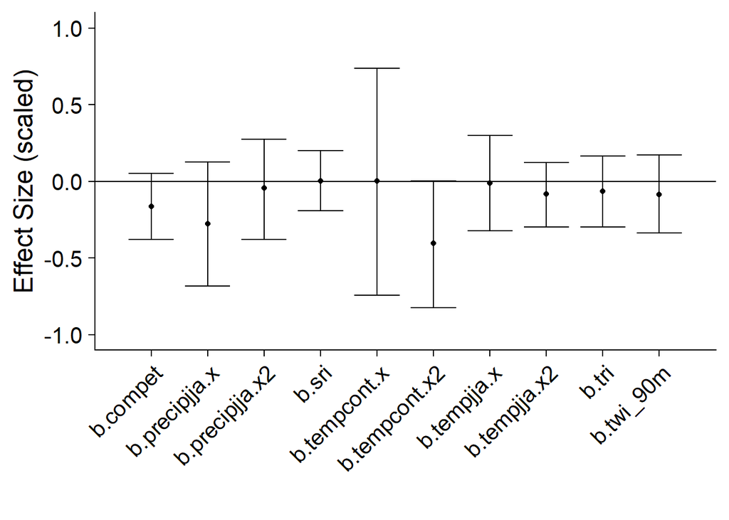

```r
(effect_size_plot.BetNan <- model_plot_function(coeff.shrub_gradient.BetNan))
```

- **negative response to temperature variability (sig)**
- slightly negative response to competition & precipitation (linear) (n.s.)

### *Cassiope tetragona*

```r
model_out.shrub_gradient.CasTet <- jags(shrub_gradient_jags.CasTet.data,    # input data
                                        inits = NULL,                       # JAGS to create initial values
                                        params,                             # parameters to be saved
                                        model.file = file.path("..", "models", "shrub_gradient.spec.jags"),
                                        n.chains = 3,                       # no. Markov chains
                                        n.iter = 50000, n.burnin = 30000,     # no. iterations & burn-in fraction per chain
                                        n.thin = 2,                         # thinning rate
                                        DIC = FALSE,                        # do not compute deviance, pD, and DIC
                                        working.directory = NULL,
                                        progress.bar = "text")
```

```r
# plot(model_out.shrub_gradient.CasTet) #check convergence, etc.
```

Extract coefficients and plot effect sizes:

```r
# extract coefficients
coeff.shrub_gradient.CasTet <- model_out.shrub_gradient.CasTet$BUGSoutput$summary %>%
  as.data.frame %>%
  select('mean','sd','2.5%','97.5%','Rhat') %>%
# add identifying info to data frame
  rownames_to_column(var = "param")
  # mutate(param = as.vector(sapply(strsplit(rownames(coeff.shrub_gradient.CasTet),"[[]",fixed=FALSE), "[", 1))) #%>% print

# add 90% CIs
ci_90.CasTet <- data.frame(q5 = NA, q95 = NA, param = NA)
for (param in 1:(length(model_out.shrub_gradient.CasTet$BUGSoutput$sims.list)-4)){
  ci_90.CasTet[param,1:2] <- quantile(data.frame(model_out.shrub_gradient.CasTet$BUGSoutput$sims.list[param])[,1], probs = c(0.05, 0.95))
  ci_90.CasTet[param, 3] <- names(data.frame(model_out.shrub_gradient.CasTet$BUGSoutput$sims.list))[param]
}

# join to coefficients table
coeff.shrub_gradient.CasTet <- coeff.shrub_gradient.CasTet %>%
  left_join(ci_90.CasTet, by = "param") %>%
  # reorder and rename cols
  select(param, mean, sd,
         l95 = "2.5%",
         l90 = q5,
         u90 = q95,
         u95 = "97.5%",
         Rhat) %>% print
```

```
##              param        mean         sd          l95         l90         u90
## 1         b.compet  -0.1617878  0.2224130   -0.5928050  -0.5215486  0.20794883
## 2    b.precipjja.x   2.3235146  2.3850797   -2.4912989  -1.3497152  6.25838564
## 3   b.precipjja.x2  -0.5769627  2.1216125   -5.0004813  -3.8978607  2.67067282
## 4            b.sri  -0.9417865  0.5411349   -2.0481659  -1.8509846 -0.07641466
## 5     b.tempcont.x  45.6496656 16.9575480   17.7418094  22.4877177 78.71371722
## 6    b.tempcont.x2   9.0966602 10.2684041  -11.3551583  -8.6077659 25.32097328
## 7      b.tempjja.x  -3.7245998  3.3684663  -11.9765542 -10.1759083  0.67667799
## 8     b.tempjja.x2  -2.9242587  3.5283625  -11.6438967  -9.3653124  1.85364729
## 9            b.tri   0.2175476  0.6445963   -1.0895694  -0.8593468  1.25386485
## 10       b.twi_90m   2.3523565  2.2779052   -2.2273633  -1.1569103  6.22958625
## 11  b_plotgroup[1] -93.9729417 61.7277944 -234.0921563          NA          NA
## 12  b_plotgroup[2] -93.7939823 64.4272631 -239.3016363          NA          NA
## 13  b_plotgroup[3] -93.7354353 63.6200932 -237.5216208          NA          NA
## 14 b_plotgroup[63] -22.4837654 12.1994209  -55.3216235          NA          NA
```

[output cut: 21 more lines]

```r
# (effect_size_plot.CasTet <- model_plot_function(coeff.shrub_gradient.CasTet))
```

- **not converging**: really large R-hat values (only 16 non-zero values)

### *Empetrum nigrum*

```r
model_out.shrub_gradient.EmpNig <- jags(shrub_gradient_jags.EmpNig.data,    # input data
                                        inits = NULL,                       # JAGS to create initial values
                                        params,                             # parameters to be saved
                                        model.file = file.path("..", "models", "shrub_gradient.spec.jags"),
                                        n.chains = 3,                       # no. Markov chains
                                        n.iter = 50000, n.burnin = 30000,     # no. iterations & burn-in fraction per chain
                                        n.thin = 2,                         # thinning rate
                                        DIC = FALSE,                        # do not compute deviance, pD, and DIC
                                        working.directory = NULL,
                                        progress.bar = "text")
```

```r
# plot(model_out.shrub_gradient.EmpNig) #check convergence, etc.
```

Extract coefficients and plot effect sizes:

```r
# extract coefficients
coeff.shrub_gradient.EmpNig <- model_out.shrub_gradient.EmpNig$BUGSoutput$summary %>%
  as.data.frame %>%
  select('mean','sd','2.5%','97.5%','Rhat') %>%
# add identifying info to data frame
  rownames_to_column(var = "param")
  # mutate(param = as.vector(sapply(strsplit(rownames(coeff.shrub_gradient.EmpNig),"[[]",fixed=FALSE), "[", 1))) #%>% print

# add 90% CIs
ci_90.EmpNig <- data.frame(q5 = NA, q95 = NA, param = NA)
for (param in 1:(length(model_out.shrub_gradient.EmpNig$BUGSoutput$sims.list)-4)){
  ci_90.EmpNig[param,1:2] <- quantile(data.frame(model_out.shrub_gradient.EmpNig$BUGSoutput$sims.list[param])[,1], probs = c(0.05, 0.95))
  ci_90.EmpNig[param, 3] <- names(data.frame(model_out.shrub_gradient.EmpNig$BUGSoutput$sims.list))[param]
}

# join to coefficients table
coeff.shrub_gradient.EmpNig <- coeff.shrub_gradient.EmpNig %>%
  left_join(ci_90.EmpNig, by = "param") %>%
  # reorder and rename cols
  select(param, mean, sd,
         l95 = "2.5%",
         l90 = q5,
         u90 = q95,
         u95 = "97.5%",
         Rhat) %>% print
```

```
##              param        mean         sd         l95         l90        u90
## 1         b.compet  0.10499738 0.09258191 -0.07687378 -0.04617589 0.25842005
## 2    b.precipjja.x  0.32734956 0.14367364  0.04760591  0.09324421 0.56428572
## 3   b.precipjja.x2 -0.05555540 0.09734169 -0.24925336 -0.21673032 0.10342857
## 4            b.sri  0.08128521 0.09640900 -0.10785836 -0.07683397 0.24134418
## 5     b.tempcont.x -0.01609581 0.26064815 -0.51737582 -0.43511010 0.41785787
## 6    b.tempcont.x2  0.08629040 0.12515737 -0.15267993 -0.11813773 0.29649439
## 7      b.tempjja.x -0.03432895 0.12732627 -0.28043811 -0.24257177 0.17985989
## 8     b.tempjja.x2 -0.15456302 0.09439724 -0.33247603 -0.30408618 0.00294436
## 9            b.tri  0.02593357 0.10415850 -0.18208550 -0.14680581 0.19526875
## 10       b.twi_90m  0.12607921 0.09788681 -0.06169169 -0.03255484 0.28632064
## 11  b_plotgroup[1] -0.09114857 0.27427847 -0.60025508          NA         NA
## 12  b_plotgroup[2] -0.26563371 0.28680930 -0.87610186          NA         NA
## 13  b_plotgroup[3]  0.02316733 0.29560075 -0.50952808          NA         NA
## 14 b_plotgroup[63] -1.68640863 0.34135563 -2.46263277          NA         NA
```

[output cut: 21 more lines]

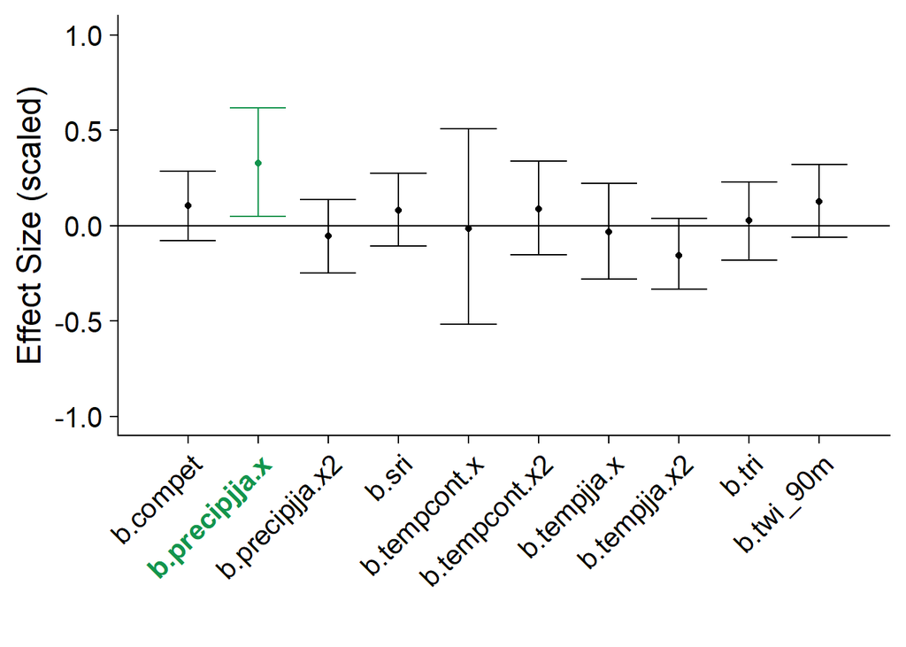

```r
# effect size plot
(effect_size_plot.BetNan <- model_plot_function(coeff.shrub_gradient.EmpNig))
```

- **positive response to precipitation (linear, sig.)**
- negative response to temperature (quadratic, n.s.)
- slightly positive response to competition, SRI and TWI (n.s.)

### *Phyllodoce caerulea*

```r
model_out.shrub_gradient.PhyCae <- jags(shrub_gradient_jags.PhyCae.data,    # input data
                                        inits = NULL,                       # JAGS to create initial values
                                        params,                             # parameters to be saved
                                        model.file = file.path("..", "models", "shrub_gradient.spec.jags"),
                                        n.chains = 3,                       # no. Markov chains
                                        n.iter = 50000, n.burnin = 30000,     # no. iterations & burn-in fraction per chain
                                        n.thin = 2,                         # thinning rate
                                        DIC = FALSE,                        # do not compute deviance, pD, and DIC
                                        working.directory = NULL,
                                        progress.bar = "text")
```

```r
# plot(model_out.shrub_gradient.PhyCae) #check convergence, etc.
```

Extract coefficients and plot effect sizes:

```r
# extract coefficients
coeff.shrub_gradient.PhyCae <- model_out.shrub_gradient.PhyCae$BUGSoutput$summary %>%
  as.data.frame %>%
  select('mean','sd','2.5%','97.5%','Rhat') %>%
# add identifying info to data frame
  rownames_to_column(var = "param")
  # mutate(param = as.vector(sapply(strsplit(rownames(coeff.shrub_gradient.PhyCae),"[[]",fixed=FALSE), "[", 1))) #%>% print

# add 90% CIs
ci_90.PhyCae <- data.frame(q5 = NA, q95 = NA, param = NA)
for (param in 1:(length(model_out.shrub_gradient.PhyCae$BUGSoutput$sims.list)-4)){
  ci_90.PhyCae[param,1:2] <- quantile(data.frame(model_out.shrub_gradient.PhyCae$BUGSoutput$sims.list[param])[,1], probs = c(0.05, 0.95))
  ci_90.PhyCae[param, 3] <- names(data.frame(model_out.shrub_gradient.PhyCae$BUGSoutput$sims.list))[param]
}

# join to coefficients table
coeff.shrub_gradient.PhyCae <- coeff.shrub_gradient.PhyCae %>%
  left_join(ci_90.PhyCae, by = "param") %>%
  # reorder and rename cols
  select(param, mean, sd,
         l95 = "2.5%",
         l90 = q5,
         u90 = q95,
         u95 = "97.5%",
         Rhat) %>% print
```

```
##              param        mean         sd         l95        l90        u90
## 1         b.compet   0.2246422  0.4589432  -0.5595445 -0.4463005  1.0359598
## 2    b.precipjja.x   2.0080200  2.9980937  -2.3354247 -1.3994208  7.5940935
## 3   b.precipjja.x2   1.0384751  2.3962686  -2.7316441 -1.7579780  5.4954802
## 4            b.sri  -1.5922928  0.8774968  -3.7655431 -3.2438859 -0.4355895
## 5     b.tempcont.x  -2.0161960  4.3309194 -12.3860463 -9.4912013  3.8037600
## 6    b.tempcont.x2  -2.1818075  2.6467740  -9.3451201 -7.2323206  0.6930393
## 7      b.tempjja.x  -0.4809945  2.3554216  -5.8513022 -4.2545341  2.9562133
## 8     b.tempjja.x2   0.7987585  1.6534344  -2.0802914 -1.2635629  3.6173399
## 9            b.tri  -0.0571471  0.8513567  -2.1855106 -1.6426378  1.1139947
## 10       b.twi_90m  -0.2663207  1.8491370  -4.5102125 -3.4419699  2.1309559
## 11  b_plotgroup[1] -18.5976247 15.3706024 -61.6639459         NA         NA
## 12  b_plotgroup[2] -18.9142660 15.3612101 -62.0593723         NA         NA
## 13  b_plotgroup[3] -18.1937565 14.6603315 -60.0610296         NA         NA
## 14 b_plotgroup[63] -12.9188605 10.8729089 -44.3251733         NA         NA
```

[output cut: 21 more lines]

- **not converged** (only 10 non-zero values)

### *Rhododendron groenlandicum*

```r
model_out.shrub_gradient.RhoGro <- jags(shrub_gradient_jags.RhoGro.data,    # input data
                                        inits = NULL,                       # JAGS to create initial values
                                        params,                             # parameters to be saved
                                        model.file = file.path("..", "models", "shrub_gradient.spec.jags"),
                                        n.chains = 3,                       # no. Markov chains
                                        n.iter = 50000, n.burnin = 30000,     # no. iterations & burn-in fraction per chain
                                        n.thin = 2,                         # thinning rate
                                        DIC = FALSE,                        # do not compute deviance, pD, and DIC
                                        working.directory = NULL,
                                        progress.bar = "text")
```

```r
# plot(model_out.shrub_gradient.RhoGro) #check convergence, etc.
```

Extract coefficients and plot effect sizes:

```r
# extract coefficients
coeff.shrub_gradient.RhoGro <- model_out.shrub_gradient.RhoGro$BUGSoutput$summary %>%
  as.data.frame %>%
  select('mean','sd','2.5%','97.5%','Rhat') %>%
# add identifying info to data frame
  rownames_to_column(var = "param")
  # mutate(param = as.vector(sapply(strsplit(rownames(coeff.shrub_gradient.RhoGro),"[[]",fixed=FALSE), "[", 1))) #%>% print

# add 90% CIs
ci_90.RhoGro <- data.frame(q5 = NA, q95 = NA, param = NA)
for (param in 1:(length(model_out.shrub_gradient.RhoGro$BUGSoutput$sims.list)-4)){
  ci_90.RhoGro[param,1:2] <- quantile(data.frame(model_out.shrub_gradient.RhoGro$BUGSoutput$sims.list[param])[,1], probs = c(0.05, 0.95))
  ci_90.RhoGro[param, 3] <- names(data.frame(model_out.shrub_gradient.RhoGro$BUGSoutput$sims.list))[param]
}

# join to coefficients table
coeff.shrub_gradient.RhoGro <- coeff.shrub_gradient.RhoGro %>%
  left_join(ci_90.RhoGro, by = "param") %>%
  # reorder and rename cols
  select(param, mean, sd,
         l95 = "2.5%",
         l90 = q5,
         u90 = q95,
         u95 = "97.5%",
         Rhat) %>% print
```

```
##              param        mean        sd        l95         l90         u90
## 1         b.compet -0.64178042 1.0215227 -2.8425730 -2.40500007  0.90136103
## 2    b.precipjja.x -0.42233254 0.2196439 -0.8630337 -0.78876391 -0.06986746
## 3   b.precipjja.x2  0.11932578 0.1771460 -0.2300382 -0.16940069  0.40910343
## 4            b.sri  0.13088181 0.1319861 -0.1154518 -0.07734541  0.35579268
## 5     b.tempcont.x  0.83028941 0.6426220 -0.3321893 -0.16869530  1.94794533
## 6    b.tempcont.x2 -0.08017556 0.3801642 -0.8302363 -0.71252491  0.54474860
## 7      b.tempjja.x -0.09528078 0.2160626 -0.5277017 -0.45221397  0.25552465
## 8     b.tempjja.x2 -0.52918309 0.1786207 -0.9034499 -0.83717547 -0.24947685
## 9            b.tri  0.03597150 0.1289268 -0.2172418 -0.17388087  0.24697356
## 10       b.twi_90m -0.15771901 0.1649165 -0.4832127 -0.42837721  0.11219599
## 11  b_plotgroup[1] -5.41055859 1.6420002 -9.0500623          NA          NA
## 12  b_plotgroup[2] -5.51815935 1.7036021 -9.3098803          NA          NA
## 13  b_plotgroup[3] -5.51803284 1.6784462 -9.2160509          NA          NA
## 14 b_plotgroup[63] -2.51557523 0.8189947 -4.2303511          NA          NA
```

[output cut: 21 more lines]

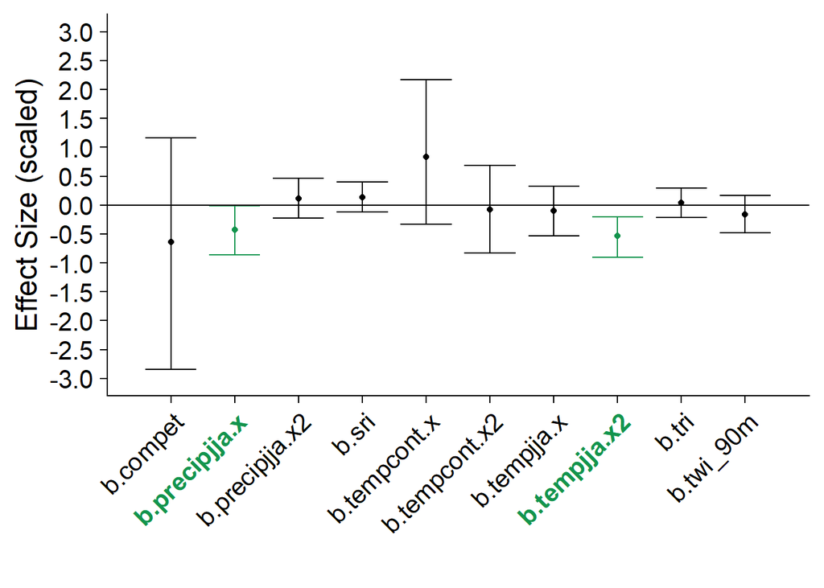

```r
# effect size plot
(effect_size_plot.RhoGro <- model_plot_function(coeff.shrub_gradient.RhoGro))
```

- **negative response to precipitation (linear, sig.) & temperature (quadratic, strongly sig.)**
- slightly positive response to SRI, temp. variation (n.s.)
- slightly negative responst to TWI (n.s.)
- large variation in competiton response as no taller-growing species in the system

### *Rhododendron tomentosum*

```r
model_out.shrub_gradient.RhoTom <- jags(shrub_gradient_jags.RhoTom.data,    # input data
                                        inits = NULL,                       # JAGS to create initial values
                                        params,                             # parameters to be saved
                                        model.file = file.path("..", "models", "shrub_gradient.spec.jags"),
                                        n.chains = 3,                       # no. Markov chains
                                        n.iter = 50000, n.burnin = 30000,     # no. iterations & burn-in fraction per chain
                                        n.thin = 2,                         # thinning rate
                                        DIC = FALSE,                        # do not compute deviance, pD, and DIC
                                        working.directory = NULL,
                                        progress.bar = "text")
```

```r
# plot(model_out.shrub_gradient.RhoTom) #check convergence, etc.
```

Extract coefficients and plot effect sizes:

```r
# extract coefficients
coeff.shrub_gradient.RhoTom <- model_out.shrub_gradient.RhoTom$BUGSoutput$summary %>%
  as.data.frame %>%
  select('mean','sd','2.5%','97.5%','Rhat') %>%
# add identifying info to data frame
  rownames_to_column(var = "param")
  # mutate(param = as.vector(sapply(strsplit(rownames(coeff.shrub_gradient.RhoTom),"[[]",fixed=FALSE), "[", 1))) #%>% print

# add 90% CIs
ci_90.RhoTom <- data.frame(q5 = NA, q95 = NA, param = NA)
for (param in 1:(length(model_out.shrub_gradient.RhoTom$BUGSoutput$sims.list)-4)){
  ci_90.RhoTom[param,1:2] <- quantile(data.frame(model_out.shrub_gradient.RhoTom$BUGSoutput$sims.list[param])[,1], probs = c(0.05, 0.95))
  ci_90.RhoTom[param, 3] <- names(data.frame(model_out.shrub_gradient.RhoTom$BUGSoutput$sims.list))[param]
}

# join to coefficients table
coeff.shrub_gradient.RhoTom <- coeff.shrub_gradient.RhoTom %>%
  left_join(ci_90.RhoTom, by = "param") %>%
  # reorder and rename cols
  select(param, mean, sd,
         l95 = "2.5%",
         l90 = q5,
         u90 = q95,
         u95 = "97.5%",
         Rhat) %>% print
```

```
##              param        mean         sd          l95         l90        u90
## 1         b.compet  -3.7556006 21.8103767  -38.7872673 -34.4289093 30.9066844
## 2    b.precipjja.x  -2.1050171  2.5037621   -8.7195175  -6.9863092  0.6849586
## 3   b.precipjja.x2   1.2624830  2.0554623   -2.2636028  -1.3964842  4.8468601
## 4            b.sri   0.2629541  0.3077613   -0.3917871  -0.2602678  0.7448479
## 5     b.tempcont.x  -1.4796291  4.1729328  -10.9397720  -8.4723958  4.3772233
## 6    b.tempcont.x2  -5.2809843  6.2594185  -23.6210680 -15.9333840 -0.1273032
## 7      b.tempjja.x   0.5830361  2.1441235   -3.5256692  -2.4112505  3.9814097
## 8     b.tempjja.x2  -0.5559223  1.4418740   -3.9486901  -2.9798861  1.3648230
## 9            b.tri   0.4317491  0.6603843   -0.9877418  -0.6971438  1.4640679
## 10       b.twi_90m  -1.9104713  1.8993977   -6.9306126  -5.7874477  0.3047176
## 11  b_plotgroup[1] -40.2673187 46.7066560 -167.4087895          NA         NA
## 12  b_plotgroup[2] -42.0324320 48.7616232 -173.7895981          NA         NA
## 13  b_plotgroup[3] -41.3770990 47.9644878 -172.3934104          NA         NA
## 14 b_plotgroup[63] -13.3979245 18.4094585  -49.2036735          NA         NA
```

[output cut: 21 more lines]

- **not converging well**: relatively large R-hat values, large variation in parameter estimates (only 13 non-zero values)

### *Salix arctophila*

```r
model_out.shrub_gradient.SalArc <- jags(shrub_gradient_jags.SalArc.data,    # input data
                                        inits = NULL,                       # JAGS to create initial values
                                        params,                             # parameters to be saved
                                        model.file = file.path("..", "models", "shrub_gradient.spec.jags"),
                                        n.chains = 3,                       # no. Markov chains
                                        n.iter = 50000, n.burnin = 30000,     # no. iterations & burn-in fraction per chain
                                        n.thin = 2,                         # thinning rate
                                        DIC = FALSE,                        # do not compute deviance, pD, and DIC
                                        working.directory = NULL,
                                        progress.bar = "text")
```

```r
# plot(model_out.shrub_gradient.SalArc) #check convergence, etc.
```

Extract coefficients and plot effect sizes:

```r
# extract coefficients
coeff.shrub_gradient.SalArc <- model_out.shrub_gradient.SalArc$BUGSoutput$summary %>%
  as.data.frame %>%
  select('mean','sd','2.5%','97.5%','Rhat') %>%
# add identifying info to data frame
  rownames_to_column(var = "param")
  # mutate(param = as.vector(sapply(strsplit(rownames(coeff.shrub_gradient.SalArc),"[[]",fixed=FALSE), "[", 1))) #%>% print

# add 90% CIs
ci_90.SalArc <- data.frame(q5 = NA, q95 = NA, param = NA)
for (param in 1:(length(model_out.shrub_gradient.SalArc$BUGSoutput$sims.list)-4)){
  ci_90.SalArc[param,1:2] <- quantile(data.frame(model_out.shrub_gradient.SalArc$BUGSoutput$sims.list[param])[,1], probs = c(0.05, 0.95))
  ci_90.SalArc[param, 3] <- names(data.frame(model_out.shrub_gradient.SalArc$BUGSoutput$sims.list))[param]
}

# join to coefficients table
coeff.shrub_gradient.SalArc <- coeff.shrub_gradient.SalArc %>%
  left_join(ci_90.SalArc, by = "param") %>%
  # reorder and rename cols
  select(param, mean, sd,
         l95 = "2.5%",
         l90 = q5,
         u90 = q95,
         u95 = "97.5%",
         Rhat) %>% print
```

```
##              param        mean         sd         l95        l90         u90
## 1         b.compet  0.24839652  0.2568698 -0.25354719 -0.1658300  0.67665808
## 2    b.precipjja.x  0.85730452  0.7074474 -0.40074332 -0.2284503  2.09642527
## 3   b.precipjja.x2 -0.81804336  0.5085606 -1.97534300 -1.7253181 -0.09266321
## 4            b.sri  0.48378447  0.3944744 -0.23594559 -0.1264236  1.17051280
## 5     b.tempcont.x  0.38416230  1.0531115 -1.62619213 -1.3486791  2.09815531
## 6    b.tempcont.x2  0.39491644  0.5332184 -0.62177586 -0.5079408  1.27528041
## 7      b.tempjja.x  0.03184959  0.4617464 -0.86760497 -0.7282979  0.77946775
## 8     b.tempjja.x2  0.17783236  0.4300344 -0.98577833 -0.5042087  0.81482707
## 9            b.tri  0.29659885  0.3796341 -0.50171541 -0.3610976  0.88834564
## 10       b.twi_90m -0.56850538  0.4474325 -1.52779724 -1.3258460  0.12238720
## 11  b_plotgroup[1] -3.40979502  1.0613780 -6.00303906         NA          NA
## 12  b_plotgroup[2] -3.34427374  1.0614802 -5.95502145         NA          NA
## 13  b_plotgroup[3] -3.52965013  1.0840532 -6.23200390         NA          NA
## 14 b_plotgroup[63] -5.82142874  1.4010174 -9.22866729         NA          NA
```

[output cut: 21 more lines]

- **not converging well**: relatively large R-hat values, quite some variation in parameter estimates (only 13 non-zero values)

### *Salix glauca*

```r
model_out.shrub_gradient.SalGla <- jags(shrub_gradient_jags.SalGla.data,    # input data
                                        inits = NULL,                       # JAGS to create initial values
                                        params,                             # parameters to be saved
                                        model.file = file.path("..", "models", "shrub_gradient.spec.jags"),
                                        n.chains = 3,                       # no. Markov chains
                                        n.iter = 50000, n.burnin = 30000,     # no. iterations & burn-in fraction per chain
                                        n.thin = 2,                         # thinning rate
                                        DIC = FALSE,                        # do not compute deviance, pD, and DIC
                                        working.directory = NULL,
                                        progress.bar = "text")
```

```r
# plot(model_out.shrub_gradient.SalGla) #check convergence, etc.
```

Extract coefficients and plot effect sizes:

```r
# extract coefficients
coeff.shrub_gradient.SalGla <- model_out.shrub_gradient.SalGla$BUGSoutput$summary %>%
  as.data.frame %>%
  select('mean','sd','2.5%','97.5%','Rhat') %>%
# add identifying info to data frame
  rownames_to_column(var = "param")
  # mutate(param = as.vector(sapply(strsplit(rownames(coeff.shrub_gradient.SalGla),"[[]",fixed=FALSE), "[", 1))) #%>% print

# add 90% CIs
ci_90.SalGla <- data.frame(q5 = NA, q95 = NA, param = NA)
for (param in 1:(length(model_out.shrub_gradient.SalGla$BUGSoutput$sims.list)-4)){
  ci_90.SalGla[param,1:2] <- quantile(data.frame(model_out.shrub_gradient.SalGla$BUGSoutput$sims.list[param])[,1], probs = c(0.05, 0.95))
  ci_90.SalGla[param, 3] <- names(data.frame(model_out.shrub_gradient.SalGla$BUGSoutput$sims.list))[param]
}

# join to coefficients table
coeff.shrub_gradient.SalGla <- coeff.shrub_gradient.SalGla %>%
  left_join(ci_90.SalGla, by = "param") %>%
  # reorder and rename cols
  select(param, mean, sd,
         l95 = "2.5%",
         l90 = q5,
         u90 = q95,
         u95 = "97.5%",
         Rhat) %>% print
```

```
##              param        mean        sd         l95         l90        u90
## 1         b.compet  0.46076634 0.1915706  0.07910678  0.14403887 0.77326176
## 2    b.precipjja.x -0.02350221 0.1823214 -0.38460321 -0.32186063 0.27044729
## 3   b.precipjja.x2 -0.07806987 0.1487031 -0.38582160 -0.32820579 0.16061479
## 4            b.sri -0.12230875 0.1166870 -0.34970688 -0.31243644 0.06909853
## 5     b.tempcont.x  0.46589007 0.3902334 -0.28806703 -0.17152856 1.11097544
## 6    b.tempcont.x2  0.06627188 0.2026364 -0.32833841 -0.26451943 0.39817709
## 7      b.tempjja.x -0.15759981 0.1572366 -0.47480359 -0.42026384 0.09731425
## 8     b.tempjja.x2 -0.08877907 0.1102755 -0.31218859 -0.27227082 0.08723786
## 9            b.tri  0.13715234 0.1199252 -0.09945573 -0.05883314 0.33441003
## 10       b.twi_90m  0.07450501 0.1366180 -0.19407995 -0.14882680 0.29849409
## 11  b_plotgroup[1] -2.31374414 0.6829226 -3.75169579          NA         NA
## 12  b_plotgroup[2] -1.93836552 0.6164443 -3.22208374          NA         NA
## 13  b_plotgroup[3] -2.37611396 0.6839069 -3.82176359          NA         NA
## 14 b_plotgroup[63] -1.50796795 0.5232767 -2.67332295          NA         NA
```

[output cut: 21 more lines]

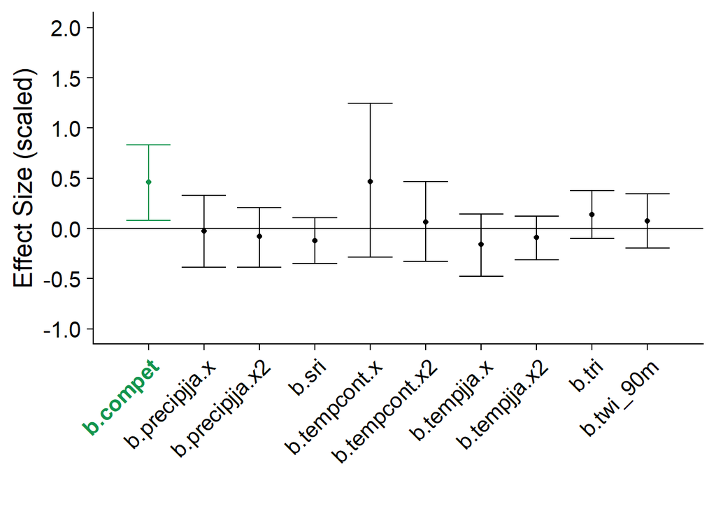

```r
# effect size plot
(effect_size_plot.SalGla <- model_plot_function(coeff.shrub_gradient.SalGla))
```

- **positive response to competition (sig.)**
- slightly negative response to temperature & SRI (n.s.)

### *Vaccinium uliginosum*

```r
model_out.shrub_gradient.VacUli <- jags(shrub_gradient_jags.VacUli.data,    # input data
                                        inits = NULL,                       # JAGS to create initial values
                                        params,                             # parameters to be saved
                                        model.file = file.path("..", "models", "shrub_gradient.spec.jags"),
                                        n.chains = 3,                       # no. Markov chains
                                        n.iter = 50000, n.burnin = 30000,     # no. iterations & burn-in fraction per chain
                                        n.thin = 2,                         # thinning rate
                                        DIC = FALSE,                        # do not compute deviance, pD, and DIC
                                        working.directory = NULL,
                                        progress.bar = "text")
```

```r
# plot(model_out.shrub_gradient.VacUli) #check convergence, etc.
```

Extract coefficients and plot effect sizes:

```r
# extract coefficients
coeff.shrub_gradient.VacUli <- model_out.shrub_gradient.VacUli$BUGSoutput$summary %>%
  as.data.frame %>%
  select('mean','sd','2.5%','97.5%','Rhat') %>%
# add identifying info to data frame
  rownames_to_column(var = "param")
  # mutate(param = as.vector(sapply(strsplit(rownames(coeff.shrub_gradient.VacUli),"[[]",fixed=FALSE), "[", 1))) #%>% print

# add 90% CIs
ci_90.VacUli <- data.frame(q5 = NA, q95 = NA, param = NA)
for (param in 1:(length(model_out.shrub_gradient.VacUli$BUGSoutput$sims.list)-4)){
  ci_90.VacUli[param,1:2] <- quantile(data.frame(model_out.shrub_gradient.VacUli$BUGSoutput$sims.list[param])[,1], probs = c(0.05, 0.95))
  ci_90.VacUli[param, 3] <- names(data.frame(model_out.shrub_gradient.VacUli$BUGSoutput$sims.list))[param]
}

# join to coefficients table
coeff.shrub_gradient.VacUli <- coeff.shrub_gradient.VacUli %>%
  left_join(ci_90.VacUli, by = "param") %>%
  # reorder and rename cols
  select(param, mean, sd,
         l95 = "2.5%",
         l90 = q5,
         u90 = q95,
         u95 = "97.5%",
         Rhat) %>% print
```

```
##              param         mean        sd        l95         l90          u90
## 1         b.compet -0.206291349 0.1220109 -0.4473924 -0.40769572 -0.005179458
## 2    b.precipjja.x -0.005685273 0.2014504 -0.3998426 -0.33577694  0.324703165
## 3   b.precipjja.x2  0.032738443 0.1499533 -0.2713225 -0.21832857  0.272650035
## 4            b.sri  0.178357303 0.1529095 -0.1061163 -0.06340523  0.438832467
## 5     b.tempcont.x -0.009427654 0.3545347 -0.6883089 -0.58060813  0.586279906
## 6    b.tempcont.x2 -0.116253755 0.1869936 -0.4762212 -0.41786057  0.197360684
## 7      b.tempjja.x  0.158453299 0.1944647 -0.2102642 -0.15096541  0.485383257
## 8     b.tempjja.x2 -0.352886239 0.1610790 -0.6869785 -0.62757278 -0.098195873
## 9            b.tri -0.107079899 0.1448599 -0.3989916 -0.35229294  0.125447823
## 10       b.twi_90m -0.277158411 0.1426540 -0.5577635 -0.51138455 -0.045577328
## 11  b_plotgroup[1] -2.563667039 0.4915583 -3.6195407          NA           NA
## 12  b_plotgroup[2] -2.608627506 0.6773493 -4.0392220          NA           NA
## 13  b_plotgroup[3] -2.032018726 0.5404279 -3.1416114          NA           NA
## 14 b_plotgroup[63] -2.212097904 0.5171685 -3.2979675          NA           NA
```

[output cut: 21 more lines]

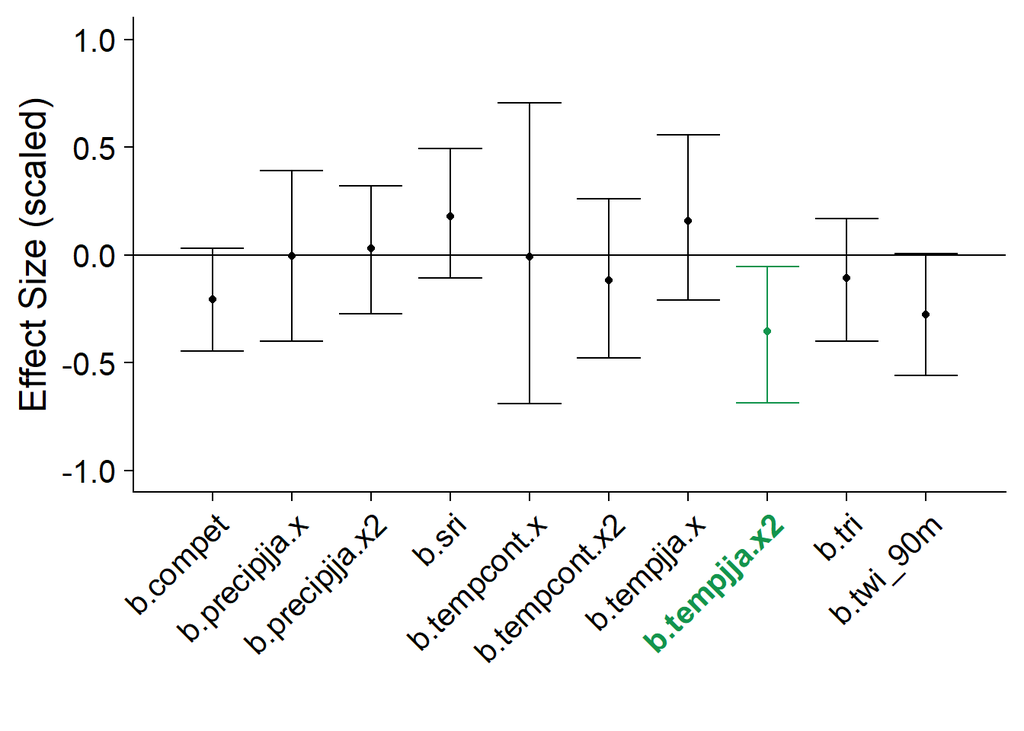

```r
# effect size plot
(effect_size_plot.VacUli <- model_plot_function(coeff.shrub_gradient.VacUli))
```

- **negative response to temperature (quadratic, sig.)**, competition, & TWI (n.s.)
- positive response to SRI (n.s.)